# February_updates

February 05, 2024

# 1 Install required packages

Install `bigWig` and `latticeExtra` package

```r
install.packages("devtools", quiet = TRUE)
library(devtools)
devtools::install_github('andrelmartins/bigWig',
              subdir='bigWig')
library(bigWig)

install.packages("DESeq2", quiet = TRUE)
install.packages("dplyr", quiet = TRUE)
```

Install `bedtools`

```bash
/bin/bash -c "$(curl -fsSL https://raw.githubusercontent.com/Homebrew/install/HEAD/install.sh)"
brew install bedtools
```

Install `Biostrings`

```r
if (!requireNamespace("Biostrings", quietly = TRUE)) {
  if (!requireNamespace("BiocManager", quietly = TRUE))
    install.packages("BiocManager")
  BiocManager::install("Biostrings")
}
```

[output not shown]

```
## Bioconductor version 3.18 (BiocManager 1.30.22), R 4.3.2 (2023-10-31)
```

```
## Installing package(s) 'Biostrings'
```

[output not shown]

```
## installing the source package 'GenomeInfoDbData'
```

[output not shown]

Install `latticeExtra`

```r
install.packages("latticeExtra", quiet = TRUE)
```

# 2 Feb 5th

# 3 RSAT - DYAD analysis

In the previous analysis, I ran the RSAT-dyad analysis, using the ENCODE DHS regions as a control for calculating the expected 3mer dyad occurrence, and generated these files with dyad patterns and the corresponding statistics.  
Command that I used:

```bash
rsat dyad-analysis -o GATA3_peak_161win_with_motif_1_RSAT_dyad.txt -i GATA3_peak_161win_with_motif_1.fasta -format FastA -l 3 -sp 0-20 -expfreq ENCODE.MCF7.DHS.background4.txt -return exp_occ,occ,ratio -sort -seqtype dna


# -1str single strand count; only the direct strand is considered for oligonucleotide and dyad occurrence counting.
# -2str count on oth strands
        #The occurrences of each oligonucleotide are summed on both strands. This allows to detect elements which act in an orientation-insensitive way (as is generally the case for yeast upstream elements).

# -type dyad_type (dr|ir|any) any   (default)
        #In order to fasten execution, the program can be asked to restrict its analysis to symmetric dyads.
        #Three types are accepted
           #dr  direct repeats: the second element is the same as the first one
           #ir  inverted repeats: the second element is the reverse complement of the first one.
           #rep  repeats: direct and inverted repeats are evaluated
           #any (default)
             #When selecting the option any, the analysis is performed on all non-symmetric dyads as well.
```

The input .fasta file has 12470 sequences, the output .txt file identified 43680 patterns.

## 3.1 coherence check – single input sequence

If we only input one sequence, what will the output look like?

```bash
source ~/miniconda3/bin/activate
conda activate rsat
cat test_single_input.fasta
#>chr10:100072622-100072723
#CAGATTTTATCATTTATTTGCTCATGTATTCACTCACTCATTAGGTCatctatttagtcaaccaacatttacttaagtccttctctattcagagctctcag

rsat dyad-analysis -o test_single_input_RSAT_dyad.txt -i test_single_input.fasta -format FastA -l 3 -sp 0-20 -expfreq ENCODE.MCF7.DHS.background4.txt -return exp_occ,occ,ratio -sort -seqtype dna
```

For this single sequence input, it generates 25662 patterns.

And if we look for cat-tca pattern, it identifies several cat-tca 3mer pair with different spacings. This is different than our customized analysis. In customized analysis, for each provided sequence, we only find one specific pattern that are closest to the peak summit. If I am looking for cat-tca pattern, then it will only give my one output.

```bash
#head test_single_input_RSAT_dyad.txt
awk -F'\t' '$1 ~ /^cat.*tca/' test_single_input_RSAT_dyad.txt | sort -k8,8nr
```

```
## catn{20}tca  catn{20}tca|tgan{20}atg 0.0005782191715       2    0.04 1   3     48.04
## catn{16}tca  catn{16}tca|tgan{16}atg 0.0005603828788       2    0.04 0   2     47.59
## catn{8}tca   catn{8}tca|tgan{8}atg   0.0005818472604       2    0.05 1   3     41.92
## catn{4}tca   catn{4}tca|tgan{4}atg   0.0005971999077       2    0.05 0   2     36.40
## catn{12}tca  catn{12}tca|tgan{12}atg 0.0005693193744       1    0.05 0   1     20.91
## catn{0}tca   catn{0}tca|tgan{0}atg   0.0006561197581       0    0.06 0   0      0.00
## catn{10}tca  catn{10}tca|tgan{10}atg 0.0005698178829       0    0.05 0   0      0.00
## catn{11}tca  catn{11}tca|tgan{11}atg 0.0005810435898       0    0.05 0   0      0.00
## catn{13}tca  catn{13}tca|tgan{13}atg 0.0005703437801       0    0.05 0   0      0.00
## catn{14}tca  catn{14}tca|tgan{14}atg 0.0006183306318       0    0.05 0   0      0.00
## catn{15}tca  catn{15}tca|tgan{15}atg 0.0005917583284       0    0.04 0   0      0.00
## catn{17}tca  catn{17}tca|tgan{17}atg 0.0005702219341       0    0.04 0   0      0.00
## catn{18}tca  catn{18}tca|tgan{18}atg 0.0005375782971       0    0.04 0   0      0.00
## catn{19}tca  catn{19}tca|tgan{19}atg 0.0005756638123       0    0.04 0   0      0.00
## catn{1}tca   catn{1}tca|tgan{1}atg   0.0006382247667       0    0.06 0   0      0.00
## catn{2}tca   catn{2}tca|tgan{2}atg   0.0005706900152       0    0.05 0   0      0.00
## catn{3}tca   catn{3}tca|tgan{3}atg   0.0007944812861       0    0.07 0   0      0.00
## catn{5}tca   catn{5}tca|tgan{5}atg   0.0005682468718       0    0.05 0   0      0.00
## catn{6}tca   catn{6}tca|tgan{6}atg   0.0005886556431       0    0.05 0   0      0.00
## catn{7}tca   catn{7}tca|tgan{7}atg   0.0006022431158       0    0.05 0   0      0.00
## catn{9}tca   catn{9}tca|tgan{9}atg   0.0005766835572       0    0.05 0   0      0.00
```

Refer to the help menu.

```bash
cd /home/FCAM/ssun/GATA3_ChIP_PRO_July2023/ChIP_final/GAT_3mer_analaysis/RSAT/
source ~/miniconda3/bin/activate
conda activate rsat
#rsat --help
rsat oligo-analysis -h
rsat create-background-model -h
rsat dyad-analysis -h
```

Files generated:  
GATA3_peak_161win_with_motif_1_RSAT_dyad.txt  
GATA3_peak_161win_with_motif_2_RSAT_dyad.txt  
GATA3_peak_161win_with_motif_4_RSAT_dyad.txt  
GATA3_peak_161win_with_motif_5_RSAT_dyad.txt  
GATA3_peak_161win_with_motif_6_RSAT_dyad.txt

```bash
head -6 GATA3_peak_161win_with_motif_1_RSAT_dyad.txt
#sequence   identifier              expected_freq   occ exp_occ ovl_occall_occ  ratio
#gatn{3}atc gatn{3}atc|gatn{3}atc   0.0000716460535   12482   85.98 36  12518    145.17
#agan{4}atc agan{4}atc|gatn{4}tct   0.0003298219842   10904  390.07 4445    15349     27.95
#atan{2}atc atan{2}atc|gatn{2}tat   0.0001616794646   10453  196.05 1460    11913     53.32
#gatn{4}tca gatn{4}tca|tgan{4}atc   0.0003742452755    7872  442.61 1728    9600      17.79
#agan{3}tat agan{3}tat|atan{3}tct   0.0002979478048    7425  357.56 613 8038      20.77
```

The first column is the sequence pattern RSAT-dyad analysis found. **Notice that the n{x} is the spacing between the elements of the dyad. The spacing is the number of bases between the end of the first element and the start of the second one.. This is different with the way we refer to as “relative distance” anchor at the G of two 3mer.** We will modify this while processing the data.

The final column represents the ratio of observed occurrences to expected occurrences (occ/exp_occ), which can serve as a rough “enrichment score”. I plan to extract patterns linked to GAT/ATC and create a bar chart or xyplot to visually depict their frequencies.  
**Notice that using this ratio may overestimate some patterns**

```bash
awk -F'\t' '$1 ~ /^gat.*atc/' GATA3_peak_161win_with_motif_1_RSAT_dyad.txt | wc -l
#21

awk -F'\t' '$1 ~ /^atc.*gat/' GATA3_peak_161win_with_motif_1_RSAT_dyad.txt  | wc -l
#21
```

**In RSAT-dyad analysis, gat-atc and atc-gat means two different structure**.

```bash
awk -F'\t' '$1 ~ /^gat.*atc/' GATA3_peak_161win_with_motif_1_RSAT_dyad.txt | sort -k8,8nr
echo " "
awk -F'\t' '$1 ~ /^atc.*gat/' GATA3_peak_161win_with_motif_1_RSAT_dyad.txt | sort -k8,8nr
```

```
## gatn{3}atc   gatn{3}atc|gatn{3}atc   0.0000716460535   12482   85.98 36  12518    145.17
## gatn{0}atc   gatn{0}atc|gatn{0}atc   0.0000515638671     614   64.15 0   614    9.57
## gatn{4}atc   gatn{4}atc|gatn{4}atc   0.0000504302144     545   59.64 6   551    9.14
## gatn{16}atc  gatn{16}atc|gatn{16}atc 0.0000944795637     590   97.70 9   599    6.04
## gatn{15}atc  gatn{15}atc|gatn{15}atc 0.0000818438092     516   85.70 8   524    6.02
## gatn{20}atc  gatn{20}atc|gatn{20}atc 0.0000942591829     547   92.71 5   552    5.90
## gatn{10}atc  gatn{10}atc|gatn{10}atc 0.0000987860472     604  109.68 6   610    5.51
## gatn{17}atc  gatn{17}atc|gatn{17}atc 0.0000906426659     503   92.61 5   508    5.43
## gatn{8}atc   gatn{8}atc|gatn{8}atc   0.0000899257860     544  102.07 7   551    5.33
## gatn{13}atc  gatn{13}atc|gatn{13}atc 0.0000906646305     516   97.24 6   522    5.31
## gatn{14}atc  gatn{14}atc|gatn{14}atc 0.0000916101649     510   97.11 9   519    5.25
## gatn{6}atc   gatn{6}atc|gatn{6}atc   0.0000971154028     591  112.60 4   595    5.25
## gatn{11}atc  gatn{11}atc|gatn{11}atc 0.0000932630475     533  102.39 9   542    5.21
## gatn{12}atc  gatn{12}atc|gatn{12}atc 0.0000888395037     493   96.41 6   499    5.11
## gatn{9}atc   gatn{9}atc|gatn{9}atc   0.0000902432624     515  101.37 12  527    5.08
## gatn{18}atc  gatn{18}atc|gatn{18}atc 0.0000939778165     466   94.81 7   473    4.92
## gatn{19}atc  gatn{19}atc|gatn{19}atc 0.0000965793592     437   96.22 4   441    4.54
## gatn{7}atc   gatn{7}atc|gatn{7}atc   0.0000847463572     423   97.33 5   428    4.35
## gatn{1}atc   gatn{1}atc|gatn{1}atc   0.0000635633129     315   78.20 1   316    4.03
## gatn{5}atc   gatn{5}atc|gatn{5}atc   0.0000883000715     258  103.60 2   260    2.49
## gatn{2}atc   gatn{2}atc|gatn{2}atc   0.0000878513418     209  106.53 0   209    1.96
##
## atcn{1}gat   atcn{1}gat|atcn{1}gat   0.0000365557250     915   44.97 6   921   20.35
## atcn{13}gat  atcn{13}gat|atcn{13}gat 0.0000915682647     986   98.21 3   989   10.04
## atcn{19}gat  atcn{19}gat|atcn{19}gat 0.0000783118818     524   78.02 10  534    6.72
## atcn{8}gat   atcn{8}gat|atcn{8}gat   0.0000890597270     659  101.08 10  669    6.52
## atcn{17}gat  atcn{17}gat|atcn{17}gat 0.0000858063102     546   87.67 8   554    6.23
## atcn{6}gat   atcn{6}gat|atcn{6}gat   0.0000802195944     562   93.01 4   566    6.04
## atcn{3}gat   atcn{3}gat|atcn{3}gat   0.0000953432975     686  114.42 1   687    6.00
## atcn{16}gat  atcn{16}gat|atcn{16}gat 0.0000842739153     521   87.15 3   524    5.98
## atcn{11}gat  atcn{11}gat|atcn{11}gat 0.0000917826817     581  100.76 7   588    5.77
## atcn{15}gat  atcn{15}gat|atcn{15}gat 0.0000847558549     510   88.75 7   517    5.75
## atcn{2}gat   atcn{2}gat|atcn{2}gat   0.0000822145577     559   99.69 0   559    5.61
## atcn{7}gat   atcn{7}gat|atcn{7}gat   0.0000795928625     495   91.41 3   498    5.42
## atcn{9}gat   atcn{9}gat|atcn{9}gat   0.0000988309276     589  111.02 2   591    5.31
## atcn{20}gat  atcn{20}gat|atcn{20}gat 0.0000944194877     481   92.87 5   486    5.18
## atcn{14}gat  atcn{14}gat|atcn{14}gat 0.0000920659368     505   97.60 7   512    5.17
## atcn{10}gat  atcn{10}gat|atcn{10}gat 0.0000804379701     458   89.30 3   461    5.13
## atcn{18}gat  atcn{18}gat|atcn{18}gat 0.0000928758991     475   93.70 3   478    5.07
## atcn{12}gat  atcn{12}gat|atcn{12}gat 0.0000918257056     501   99.65 2   503    5.03
## atcn{4}gat   atcn{4}gat|atcn{4}gat   0.0000924786758     548  109.37 0   548    5.01
## atcn{5}gat   atcn{5}gat|atcn{5}gat   0.0000961865213     534  112.85 2   536    4.73
## atcn{0}gat   atcn{0}gat|atcn{0}gat   0.0000150225440      44   18.69 0   44     2.35
```

**Notice that:**  
1) the x value of n{x} (spacings) in RSAT is defined differently than in the customized analysis. For instance, gatn{3}atc has what we define in customized analysis as a 8bp relative distance between the G in gat and C in atc.  
2) Notice the second column–“identifier”.

**On the other hand, gat-gat and atc-atc means same structure**.

```bash
awk -F'\t' '$1 ~ /^gat.*gat/' GATA3_peak_161win_with_motif_1_RSAT_dyad.txt | sort -k8,8nr
```

```bash
awk -F'\t' '$1 ~ /^atc.*atc/' GATA3_peak_161win_with_motif_1_RSAT_dyad.txt | sort -k8,8nr
```

```
## atcn{2}atc   atcn{2}atc|gatn{2}gat   0.0001743278582    3755  211.39 179 3934      17.76
## atcn{19}atc  atcn{19}atc|gatn{19}gat 0.0001834690131    1423  182.79 61  1484       7.78
## atcn{7}atc   atcn{7}atc|gatn{7}gat   0.0001966917141    1525  225.90 90  1615       6.75
## atcn{10}atc  atcn{10}atc|gatn{10}gat 0.0002081405868    1541  231.08 90  1631       6.67
## atcn{9}atc   atcn{9}atc|gatn{9}gat   0.0002062495205    1427  231.68 145 1572       6.16
## atcn{5}atc   atcn{5}atc|gatn{5}gat   0.0001401253129     970  164.40 81  1051       5.90
## atcn{12}atc  atcn{12}atc|gatn{12}gat 0.0001884293340    1200  204.49 69  1269       5.87
## atcn{20}atc  atcn{20}atc|gatn{20}gat 0.0001875565375    1068  184.47 62  1130       5.79
## atcn{8}atc   atcn{8}atc|gatn{8}gat   0.0001814393467    1159  205.94 53  1212       5.63
## atcn{15}atc  atcn{15}atc|gatn{15}gat 0.0002001648218    1151  209.60 86  1237       5.49
## atcn{16}atc  atcn{16}atc|gatn{16}gat 0.0001767432755     998  182.77 59  1057       5.46
## atcn{14}atc  atcn{14}atc|gatn{14}gat 0.0001838280257    1035  194.87 73  1108       5.31
## atcn{13}atc  atcn{13}atc|gatn{13}gat 0.0001850944034    1024  198.52 97  1121       5.16
## atcn{4}atc   atcn{4}atc|gatn{4}gat   0.0001842588721    1102  217.92 36  1138       5.06
## atcn{11}atc  atcn{11}atc|gatn{11}gat 0.0001856378756    1013  203.80 60  1073       4.97
## atcn{18}atc  atcn{18}atc|gatn{18}gat 0.0001950393881     960  196.77 52  1012       4.88
## atcn{17}atc  atcn{17}atc|gatn{17}gat 0.0001901779857     942  194.30 111 1053       4.85
## atcn{6}atc   atcn{6}atc|gatn{6}gat   0.0001786128314     991  207.10 39  1030       4.79
## atcn{0}atc   atcn{0}atc|gatn{0}gat   0.0003333380702    1643  414.73 41  1684       3.96
## atcn{3}atc   atcn{3}atc|gatn{3}gat   0.0001916566577     851  230.00 59  910    3.70
## atcn{1}atc   atcn{1}atc|gatn{1}gat   0.0001617727236     690  199.01 53  743    3.47
```

Extract the pattern info we need.

```r
library(Biostrings)
process_and_subset_RSAT <- function(file_path, pattern1, pattern2, number) {
  # Read the file
  input_data <- read.table(file_path, header = FALSE, sep = "\t")

  # Split the first column into components
  components_list <- strsplit(input_data$V1, "n\\{|\\}")

  processed_data <- data.frame(
    first = sapply(components_list, function(x) x[1]),
    dyad_distance = as.numeric(sapply(components_list, function(x) x[2])),
    second = sapply(components_list, function(x) x[3]),
    ratio = input_data$V8 # ratio
  )
  # patterns to DNAstring
  pattern1<-DNAString(pattern1)
  pattern2<-DNAString(pattern2)
  # Get the reverse complement of the patterns
  rc_pattern1 <- reverseComplement(pattern1)
  rc_pattern2 <- reverseComplement(pattern2)

  # Subset the dataframe based on the specified patterns and their reverse complements
  if (pattern1 == pattern2) {
    # Get the reverse complement of the patterns
    rc_pattern1 <- reverseComplement(pattern1)
    rc_pattern2 <- reverseComplement(pattern2)

    # Subset the dataframe based on the specified patterns and their reverse complements
    dyad_structure <- processed_data[grepl(pattern1, processed_data$first, ignore.case = TRUE) & grepl(pattern2, processed_data$second, ignore.case = TRUE), ]
    dyad_structure_rc <- processed_data[grepl(rc_pattern1, processed_data$first, ignore.case = TRUE) & grepl(rc_pattern2, processed_data$second, ignore.case = TRUE), ]

    output_data <- rbind(dyad_structure, dyad_structure_rc)
  } else {
    # If patterns are not the same, only subset based on pattern1 and pattern2
    output_data <- processed_data[grepl(pattern1, processed_data$first, ignore.case = TRUE) & grepl(pattern2, processed_data$second, ignore.case = TRUE), ]
  }

  # Order by descending ratio
  output_data <- output_data[order(-output_data$ratio), ]

  # Add the relative distance column
  output_data$relative_distance <- output_data$dyad_distance + number

  return(output_data)
}


GAT_GAT <- process_and_subset_RSAT("./GATA3_peak_161win_with_motif_1_RSAT_dyad.txt", "GAT", "GAT", 3)
GAT_ATC <- process_and_subset_RSAT("./GATA3_peak_161win_with_motif_1_RSAT_dyad.txt", "GAT", "ATC", 5)

nrow(GAT_GAT)
```

```
## [1] 21
```

```r
head(GAT_GAT)
```

```
##      first dyad_distance second ratio relative_distance
## 28     atc             2    atc 17.76                 5
## 1603   atc            19    atc  7.78                22
## 1264   atc             7    atc  6.75                10
## 1219   atc            10    atc  6.67                13
## 1583   atc             9    atc  6.16                12
## 5986   atc             5    atc  5.90                 8
```

```r
nrow(GAT_ATC)
```

```
## [1] 21
```

```r
head(GAT_ATC)
```

```
##       first dyad_distance second  ratio relative_distance
## 1       gat             3    atc 145.17                 8
## 15239   gat             0    atc   9.57                 5
## 18183   gat             4    atc   9.14                 9
## 16303   gat            16    atc   6.04                21
## 19417   gat            15    atc   6.02                20
## 18091   gat            20    atc   5.90                25
```

```r
GAT_GAT$query_status="same_strand_GAT"
GAT_ATC$query_status="opposite_strand_GAT"
df.plot=rbind(GAT_GAT, GAT_ATC)
str(df.plot)
```

```
## 'data.frame':    42 obs. of  6 variables:
##  $ first            : chr  "atc" "atc" "atc" "atc" ...
##  $ dyad_distance    : num  2 19 7 10 9 5 12 20 8 15 ...
##  $ second           : chr  "atc" "atc" "atc" "atc" ...
##  $ ratio            : num  17.76 7.78 6.75 6.67 6.16 ...
##  $ relative_distance: num  5 22 10 13 12 8 15 23 11 18 ...
##  $ query_status     : chr  "same_strand_GAT" "same_strand_GAT" "same_strand_GAT" "same_strand_GAT" ...
```

```r
unique(df.plot$query_status)
```

```
## [1] "same_strand_GAT"     "opposite_strand_GAT"
```

```r
#[1] "same_strand_GAT"     "opposite_strand_GAT"
head(df.plot)
```

```
##      first dyad_distance second ratio relative_distance    query_status
## 28     atc             2    atc 17.76                 5 same_strand_GAT
## 1603   atc            19    atc  7.78                22 same_strand_GAT
## 1264   atc             7    atc  6.75                10 same_strand_GAT
## 1219   atc            10    atc  6.67                13 same_strand_GAT
## 1583   atc             9    atc  6.16                12 same_strand_GAT
## 5986   atc             5    atc  5.90                 8 same_strand_GAT
```

```r
df.plot$query_status = factor(df.plot$query_status, levels = c("same_strand_GAT", "opposite_strand_GAT"))
nrow(df.plot)
```

```
## [1] 42
```

```r
#42
summary(df.plot)
```

```
##     first           dyad_distance    second              ratio
##  Length:42          Min.   : 0    Length:42          Min.   :  1.960
##  Class :character   1st Qu.: 5    Class :character   1st Qu.:  4.890
##  Mode  :character   Median :10    Mode  :character   Median :  5.310
##                     Mean   :10                       Mean   :  8.977
##                     3rd Qu.:15                       3rd Qu.:  5.900
##                     Max.   :20                       Max.   :145.170
##  relative_distance              query_status
##  Min.   : 3        same_strand_GAT    :21
##  1st Qu.: 9        opposite_strand_GAT:21
##  Median :14
##  Mean   :14
##  3rd Qu.:19
##  Max.   :25
```

xyplot

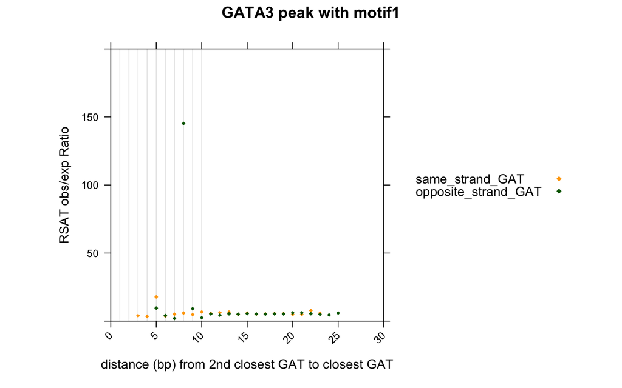

```r
library(lattice)
library(latticeExtra)
  xyplot(ratio ~ relative_distance,
         data = df.plot,
         groups = query_status,
         #auto.key=TRUE,
         #auto.key = list(space = "right", lines=F, points=TRUE, cex = 1),
         auto.key=list(space="right", points=TRUE),
                       #title="2nd 3mer relative to the anchor", cex.title=1),
         aspect = 1,
         xlim=c(0,30),
         ylim=c(0, 200),
         #type = c('p', 'smooth'),
         xlab = "distance (bp) from 2nd closest GAT to closest GAT",
         ylab="RSAT obs/exp Ratio",
         main="GATA3 peak with motif1",
         between=list(y=1.0),
         scales = list(x = list(rot = 45, at = seq(from = 0, to = 50, by = 5))),
         par.settings = list(superpose.symbol = list(col=c("orange", "darkgreen"), pch=18, lwd=2), strip.background=list(col="grey85")),
         panel = function(x,y,...) {panel.abline(v=c(seq(1, 10, 1)), col = "grey90")

                                      panel.xyplot(x, y,
                                                   col=c("orange","darkgreen"),
                                                   pch=18,
                                                   cex=0.6,...)
                                      #panel.barchart(x,y, horizontal = FALSE, col=c("red", "blue"), alpha=0.4)


  })
```

Loop through RSAT results use the other positive controls, extract the relative dyad patterns and make a xy/barchart:

```r
library(Biostrings)
library(lattice)
library(latticeExtra)

#function
process_and_subset_RSAT <- function(file_path, pattern1, pattern2, number) {
  # Read the file
  input_data <- read.table(file_path, header = FALSE, sep = "\t")

  # Split the first column into components
  components_list <- strsplit(input_data$V1, "n\\{|\\}")

  processed_data <- data.frame(
    first = sapply(components_list, function(x) x[1]),
    dyad_distance = as.numeric(sapply(components_list, function(x) x[2])),
    second = sapply(components_list, function(x) x[3]),
    ratio = input_data$V8 # ratio
  )
  # patterns to DNAstring
  pattern1<-DNAString(pattern1)
  pattern2<-DNAString(pattern2)
  # Get the reverse complement of the patterns
  rc_pattern1 <- reverseComplement(pattern1)
  rc_pattern2 <- reverseComplement(pattern2)

  # Subset the dataframe based on the specified patterns and their reverse complements
  if (pattern1 == pattern2) {
    # Get the reverse complement of the patterns
    rc_pattern1 <- reverseComplement(pattern1)
    rc_pattern2 <- reverseComplement(pattern2)

    # Subset the dataframe based on the specified patterns and their reverse complements
    dyad_structure <- processed_data[grepl(pattern1, processed_data$first, ignore.case = TRUE) & grepl(pattern2, processed_data$second, ignore.case = TRUE), ]
    dyad_structure_rc <- processed_data[grepl(rc_pattern1, processed_data$first, ignore.case = TRUE) & grepl(rc_pattern2, processed_data$second, ignore.case = TRUE), ]

    output_data <- rbind(dyad_structure, dyad_structure_rc)
  } else {
    # If patterns are not the same, only subset based on pattern1 and pattern2
    output_data <- processed_data[grepl(pattern1, processed_data$first, ignore.case = TRUE) & grepl(pattern2, processed_data$second, ignore.case = TRUE), ]
  }

  # Order by descending ratio
  output_data <- output_data[order(-output_data$ratio), ]

  # Add the relative distance column
  output_data$relative_distance <- output_data$dyad_distance + number

  return(output_data)
}

#loop through files
for (dyad.results in Sys.glob(file.path("./GATA3_peak_161win_with_motif_*_RSAT_dyad.txt")))  {
    print(dyad.results)
    motif.name = paste0("motif", strsplit((strsplit(strsplit(dyad.results, "/")[[1]][length(strsplit(dyad.results, "/")[[1]])], 'GATA3_peak_161win_with_motif_')[[1]][2]), "_RSAT_dyad.txt")[[1]][1])
    print(motif.name)
    GAT_GAT <- process_and_subset_RSAT(dyad.results, "GAT", "GAT", 3)
    GAT_ATC <- process_and_subset_RSAT(dyad.results, "GAT", "ATC", 5)
    nrow(GAT_GAT)
    head(GAT_GAT)
    nrow(GAT_ATC)
    head(GAT_ATC)
    GAT_GAT$query_status="same_strand_GAT"
    GAT_ATC$query_status="opposite_strand_GAT"
    df.plot=rbind(GAT_GAT, GAT_ATC)
    str(df.plot)

    unique(df.plot$query_status)
    #[1] "same_strand_GAT"     "opposite_strand_GAT"
    head(df.plot)
    df.plot$query_status = factor(df.plot$query_status, levels = c("same_strand_GAT", "opposite_strand_GAT"))
    nrow(df.plot)

    summary(df.plot)
    pdf(paste0('xy_RSAT_dyad_closest_2nd_GAT_to_closest_1st_GAT_GATA3_peak_with_', motif.name, '.pdf'), width=15,height=5)
print(
  xyplot(ratio ~ relative_distance,
         data = df.plot,
         groups = query_status,
         #auto.key=TRUE,
         #auto.key = list(space = "right", lines=F, points=TRUE, cex = 1),
         auto.key=list(space="right", points=TRUE),
                       #title="2nd 3mer relative to the anchor", cex.title=1),
         aspect = 1,
         xlim=c(0,30),
         ylim=c(0, 200),
         #type = c('p', 'smooth'),
         xlab = "distance (bp) from 2nd closest GAT to closest GAT",
         ylab="RSAT obs/exp Ratio",
         main=paste0("GATA3 peak with ", motif.name),
         between=list(y=1.0),
         scales = list(x = list(rot = 45, at = seq(from = 0, to = 50, by = 5))),
         par.settings = list(superpose.symbol = list(col=c("orange", "darkgreen"), pch=18, lwd=2), strip.background=list(col="grey85")),
         panel = function(x,y,...) {panel.abline(v=c(seq(1, 10, 1)), col = "grey90")

                                      panel.xyplot(x, y,
                                                   col=c("orange","darkgreen"),
                                                   pch=18,
                                                   cex=0.6,...)
                                      #panel.barchart(x,y, horizontal = FALSE, col=c("red", "blue"), alpha=0.4)


  })
)
dev.off()
}
```

### 3.1.1 RSAT–motif5

In the previous analysis, we extracted dyad structures anchored at “GAT.” However, we have discussed the sensitivity of RSAT analysis to structures with two reverse-complement dyads. For motif5 analysis, we aim to focus on structures anchored specifically at “ATC” to ensure we identify the correct structure.

```r
library(Biostrings)

process_and_subset_RSAT <- function(file_path, pattern1, pattern2, number) {
  # Read the file
  input_data <- read.table(file_path, header = FALSE, sep = "\t")

  # Split the first column into components
  components_list <- strsplit(input_data$V1, "n\\{|\\}")

  processed_data <- data.frame(
    first = sapply(components_list, function(x) x[1]),
    dyad_distance = as.numeric(sapply(components_list, function(x) x[2])),
    second = sapply(components_list, function(x) x[3]),
    ratio = input_data$V8 # ratio
  )
  # patterns to DNAstring
  pattern1<-DNAString(pattern1)
  pattern2<-DNAString(pattern2)
  # Get the reverse complement of the patterns
  rc_pattern1 <- reverseComplement(pattern1)
  rc_pattern2 <- reverseComplement(pattern2)

  # Subset the dataframe based on the specified patterns and their reverse complements
  if (pattern1 == pattern2) {
    # Get the reverse complement of the patterns
    rc_pattern1 <- reverseComplement(pattern1)
    rc_pattern2 <- reverseComplement(pattern2)

    # Subset the dataframe based on the specified patterns and their reverse complements
    dyad_structure <- processed_data[grepl(pattern1, processed_data$first, ignore.case = TRUE) & grepl(pattern2, processed_data$second, ignore.case = TRUE), ]
    dyad_structure_rc <- processed_data[grepl(rc_pattern1, processed_data$first, ignore.case = TRUE) & grepl(rc_pattern2, processed_data$second, ignore.case = TRUE), ]

    output_data <- rbind(dyad_structure, dyad_structure_rc)
  } else {
    # If patterns are not the same, only subset based on pattern1 and pattern2
    output_data <- processed_data[grepl(pattern1, processed_data$first, ignore.case = TRUE) & grepl(pattern2, processed_data$second, ignore.case = TRUE), ]
  }

  # Order by descending ratio
  output_data <- output_data[order(-output_data$ratio), ]

  # Add the relative distance column
  output_data$relative_distance <- output_data$dyad_distance + number

  return(output_data)
}


ATC_GAT <- process_and_subset_RSAT("./GATA3_peak_161win_with_motif_5_RSAT_dyad.txt", "ATC", "GAT", 1)
ATC_ATC <- process_and_subset_RSAT("./GATA3_peak_161win_with_motif_5_RSAT_dyad.txt", "ATC", "ATC", 3)

nrow(ATC_GAT)
```

```
## [1] 21
```

```r
head(ATC_GAT)
```

```
##       first dyad_distance second  ratio relative_distance
## 3       atc             1    gat 271.11                 2
## 7076    atc             8    gat   8.94                 9
## 11672   atc            10    gat   8.03                11
## 12399   atc             6    gat   7.49                 7
## 14492   atc             7    gat   6.98                 8
## 12923   atc            14    gat   6.96                15
```

```r
nrow(ATC_ATC)
```

```
## [1] 21
```

```r
head(ATC_ATC)
```

```
##      first dyad_distance second ratio relative_distance
## 14     atc             2    atc 21.52                 5
## 342    atc             9    atc  8.47                12
## 849    atc             6    atc  7.87                 9
## 855    atc            10    atc  7.04                13
## 1116   atc             4    atc  6.87                 7
## 2937   atc            11    atc  5.81                14
```

```r
ATC_ATC$query_status="same_strand_ATC"
ATC_GAT$query_status="opposite_strand_ATC"
df.plot=rbind(ATC_ATC, ATC_GAT)
str(df.plot)
```

```
## 'data.frame':    42 obs. of  6 variables:
##  $ first            : chr  "atc" "atc" "atc" "atc" ...
##  $ dyad_distance    : num  2 9 6 10 4 11 7 12 14 16 ...
##  $ second           : chr  "atc" "atc" "atc" "atc" ...
##  $ ratio            : num  21.52 8.47 7.87 7.04 6.87 ...
##  $ relative_distance: num  5 12 9 13 7 14 10 15 17 19 ...
##  $ query_status     : chr  "same_strand_ATC" "same_strand_ATC" "same_strand_ATC" "same_strand_ATC" ...
```

```r
unique(df.plot$query_status)
```

```
## [1] "same_strand_ATC"     "opposite_strand_ATC"
```

```r
head(df.plot)
```

```
##      first dyad_distance second ratio relative_distance    query_status
## 14     atc             2    atc 21.52                 5 same_strand_ATC
## 342    atc             9    atc  8.47                12 same_strand_ATC
## 849    atc             6    atc  7.87                 9 same_strand_ATC
## 855    atc            10    atc  7.04                13 same_strand_ATC
## 1116   atc             4    atc  6.87                 7 same_strand_ATC
## 2937   atc            11    atc  5.81                14 same_strand_ATC
```

```r
df.plot$query_status = factor(df.plot$query_status, levels = c("same_strand_ATC", "opposite_strand_ATC"))
nrow(df.plot)
```

```
## [1] 42
```

```r
#42
summary(df.plot)
```

```
##     first           dyad_distance    second              ratio
##  Length:42          Min.   : 0    Length:42          Min.   :  1.850
##  Class :character   1st Qu.: 5    Class :character   1st Qu.:  4.540
##  Mode  :character   Median :10    Mode  :character   Median :  5.520
##                     Mean   :10                       Mean   : 12.089
##                     3rd Qu.:15                       3rd Qu.:  6.845
##                     Max.   :20                       Max.   :271.110
##  relative_distance              query_status
##  Min.   : 1        same_strand_ATC    :21
##  1st Qu.: 7        opposite_strand_ATC:21
##  Median :12
##  Mean   :12
##  3rd Qu.:17
##  Max.   :23
```

xyplot

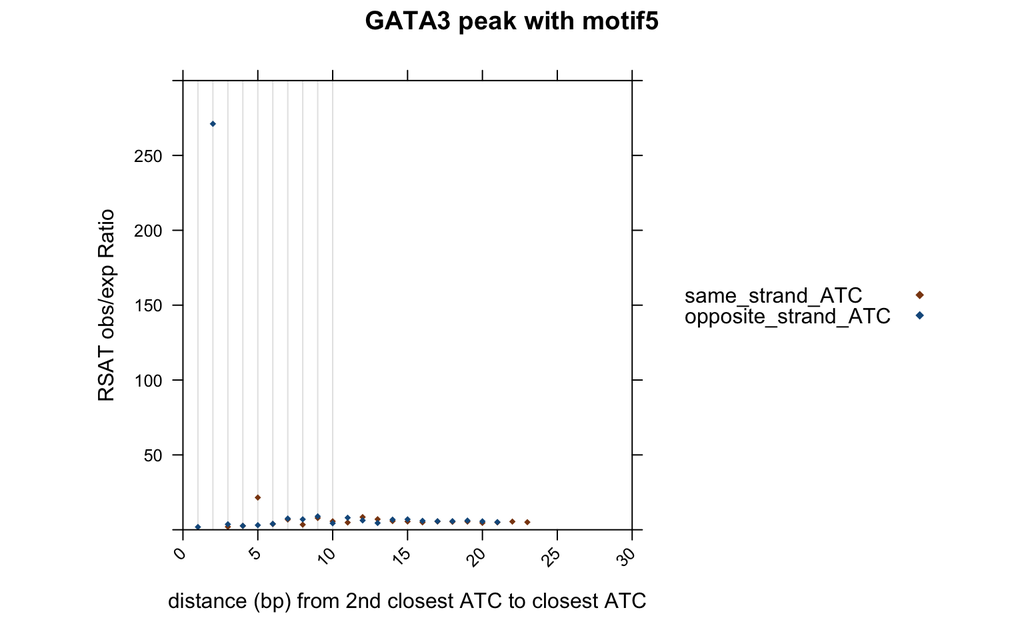

```r
library(lattice)
library(latticeExtra)
#pdf(paste0('xy_RSAT_dyad_closest_2nd_ATC_to_closest_1st_ATC_GATA3_peak_with_motif5.pdf'), width=10,height=5)
#print(
  xyplot(ratio ~ relative_distance,
         data = df.plot,
         groups = query_status,
         #auto.key=TRUE,
         #auto.key = list(space = "right", lines=F, points=TRUE, cex = 1),
         auto.key=list(space="right", points=TRUE),
                       #title="2nd 3mer relative to the anchor", cex.title=1),
         aspect = 1,
         xlim=c(0,30),
         ylim=c(0, 300),
         #type = c('p', 'smooth'),
         xlab = "distance (bp) from 2nd closest ATC to closest ATC",
         ylab="RSAT obs/exp Ratio",
         main="GATA3 peak with motif5",
         between=list(y=1.0),
         scales = list(x = list(rot = 45, at = seq(from = 0, to = 50, by = 5))),
         par.settings = list(superpose.symbol = list(col=c("#8B4513", "#145A8C"), pch=18, lwd=2), strip.background=list(col="grey85")),
         panel = function(x,y,...) {panel.abline(v=c(seq(1, 10, 1)), col = "grey90")

                                      panel.xyplot(x, y,
                                                   col=c("#8B4513", "#145A8C"),
                                                   pch=18,
                                                   cex=0.6,...)
                                      #panel.barchart(x,y, horizontal = FALSE, col=c("red", "blue"), alpha=0.4)


  })
```

```r
#)
#dev.off()
```

# 4 Comparison between RSAT and customized analysis

For the customized analysis:

1. Merge the occurrences of the anchored GAT on both the plus and minus strands.
2. Determine the second closest GAT relative to the strandedness of the anchored GAT. For example, if anchoring at GAT (regardless of its strand), the “minus-GAT” trace should be the sum of the occurrences of “+GAT” anchored at -GAT and “-GAT” anchored at +GAT.
3. Calculate the relative frequencies (y-axis in plots) as the actual occurrences of the pattern minus the frequencies from the DHS negative control.

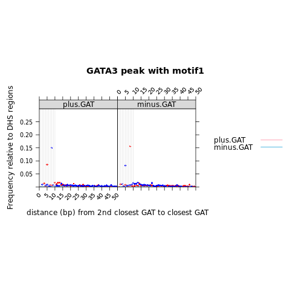

Figure 1: xy plot of GATA3 peak with motif1 relative to the DHS regions: 3mer structure

```r
# define function
calculate_actual_frequency <- function(data) {
  # Use table() to create a frequency table
  actual_frequencies <- table(data)/length(data)
  result <- data.frame(value = names(actual_frequencies), actual_freq = as.vector(actual_frequencies))
  return(result)
}


my_motifs = c("motif1", "motif4","motif2", "motif6", "motif5")
for (motif in my_motifs) {
  print(motif)
  #GATA peaks
  df.plot.GATA = data.frame(matrix(nrow = 0, ncol = 5))
  colnames(df.plot.GATA) = c("dis","anchor_status", "query_status","abs.dis", "actual_freq")
  for (closest_2nd_dis in Sys.glob(file.path(paste0("./closest.2nd*GAT.to.1st*GAT.GATA3.", motif, ".bed")))) {
    print(closest_2nd_dis)
    anchor_status =strsplit((strsplit(strsplit(closest_2nd_dis, "/")[[1]][length(strsplit(closest_2nd_dis, "/")[[1]])], 'closest.2nd.*.to.1st.')[[1]][2]), paste0(".GATA3.", motif, ".bed"))[[1]][1]
    print(anchor_status)
    query_status =strsplit((strsplit(strsplit(closest_2nd_dis, "/")[[1]][length(strsplit(closest_2nd_dis, "/")[[1]])], 'closest.2nd.')[[1]][2]), paste0(".to.1st.*.GATA3.", motif, ".bed"))[[1]][1]
    print(query_status)
    temp = as.data.frame(cbind(read.table(closest_2nd_dis, header=F, comment.char='')[,11], anchor_status, query_status))
    colnames(temp) = c("dis", "anchor_status", "query_status")
    temp$dis=as.integer(temp$dis)
    temp$abs.dis=abs(temp$dis)
    actual_frequencies = calculate_actual_frequency(temp$abs.dis)
    temp1= merge(temp, actual_frequencies, by.x = "abs.dis", by.y = "value", all.x = TRUE)
    df.plot.GATA = rbind(df.plot.GATA,temp1)
  }
  df.plot.GATA$anchor_status = factor(df.plot.GATA$anchor_status, levels = c("plus.GAT", "minus.GAT"))
  df.plot.GATA$query_status = factor(df.plot.GATA$query_status, levels = c("plus.GAT", "minus.GAT"))
  uniq.df.plot.GATA=df.plot.GATA[!duplicated(df.plot.GATA), ]


  #DHS regions
  df.plot.DHS = data.frame(matrix(nrow = 0, ncol = 5))
colnames(df.plot.DHS) = c("dis","anchor_status", "query_status","abs.dis", "actual_freq_neg")
for (closest_2nd_dis in Sys.glob(file.path("./closest.2nd*GAT.to.1st*GAT.indep.DHS.bed"))) {
    print(closest_2nd_dis)
    anchor_status =strsplit((strsplit(strsplit(closest_2nd_dis, "/")[[1]][length(strsplit(closest_2nd_dis, "/")[[1]])], 'closest.2nd.*.to.1st.')[[1]][2]), ".indep.DHS.bed")[[1]][1]
    print(anchor_status)
    query_status =strsplit((strsplit(strsplit(closest_2nd_dis, "/")[[1]][length(strsplit(closest_2nd_dis, "/")[[1]])], 'closest.2nd.')[[1]][2]), ".to.1st.*.indep.DHS.bed")[[1]][1]
    print(query_status)
    temp = as.data.frame(cbind(read.table(closest_2nd_dis, header=F, comment.char='')[,11], anchor_status, query_status))
    colnames(temp) = c("dis", "anchor_status", "query_status")
    temp$dis=as.integer(temp$dis)
    temp$abs.dis=abs(temp$dis)
    actual_frequency = calculate_actual_frequency(temp$abs.dis)
    temp1= merge(temp, actual_frequency, by.x = "abs.dis", by.y = "value", all.x = TRUE)
    df.plot.DHS = rbind(df.plot.DHS, temp1)
}
    colnames(df.plot.DHS)[5]="actual_freq_DHS"
    df.plot.DHS$anchor_status = factor(df.plot.DHS$anchor_status, levels = c("plus.GAT", "minus.GAT"))
    df.plot.DHS$query_status = factor(df.plot.DHS$query_status, levels = c("plus.GAT", "minus.GAT"))
    uniq.df.plot.DHS=df.plot.DHS[!duplicated(df.plot.DHS), ]
    #nrow(uniq.df.plot.DHS) #[1] 2859

  #calculate the relative frequency
    #by subtraction of actual frequency between GATA3 peaks and DHS regions
    df.plot=merge(uniq.df.plot.GATA, uniq.df.plot.DHS, by=c("abs.dis", "dis", "anchor_status", "query_status"), all.x = TRUE)
    df.plot$rel_freq <- ifelse(is.na(df.plot$actual_freq_DHS), NA, df.plot$actual_freq - df.plot$actual_freq_DHS)
    df.plot$strand_relationship <- ifelse(df.plot$anchor_status == df.plot$query_status,
                                              "same_strand_GAT", "opposite_strand_GAT")

    df.plot$strand_relationship = factor(df.plot$strand_relationship, levels = c("same_strand_GAT", "opposite_strand_GAT"))

library(lattice)
library(latticeExtra)
pdf(paste0('xy_closest_2nd_GAT_to_closest_1st_GAT_to_GATA3_pos_', motif, '_compare_to_DHS.pdf'), width=15,height=5)
print(xyplot(rel_freq ~ abs.dis,
         data = df.plot,
         groups = strand_relationship,
         auto.key = list(space = "right", lines=TRUE, points=FALSE, cex = 1),
         aspect = 1,
         xlim=c(0,50),
         ylim=c(0, 0.3),
         #type = c('p', 'smooth'),
         xlab = "distance (bp) from 2nd closest GAT to closest GAT",
         ylab="Frequency relative to DHS regions",
         main=paste0("GATA3 peak with ", motif),
         between=list(y=1.0),
         scales = list(x = list(rot = 45, at = seq(from = 0, to = 50, by = 5))),
         par.settings = list(superpose.line = list(col=c("pink", "skyblue"), lwd=2), strip.background=list(col="grey85")),
         panel = function(x,y,...) {panel.densityplot(x, data = df.plot,
                                                        from=0,
                                                        to=50,
                                                        lty = c(1),
                                                        lwd=2,
                                                        darg=list(bw = "nrd0", kernel="gaussian"),
                                                        type = "count",
                                                        col=c("pink","skyblue"), ...)
                                      panel.xyplot(x, y,
                                                   col=c("red","blue"),
                                                   pch=18,
                                                   cex=0.6,...)
                                      panel.abline(v=c(seq(1, 10, 1)), col = "grey90")

  })
)
dev.off()

png(paste0('xy_closest_2nd_GAT_to_closest_1st_GAT_to_GATA3_pos_', motif, '_compare_to_DHS.png'))
print(xyplot(rel_freq ~ abs.dis | anchor_status,
         #data = df.plot[!duplicated(df.plot), ],
         data = df.plot,
         groups = query_status,
         auto.key = list(space = "right", lines=TRUE, points=FALSE, cex = 1),
         aspect = 1,
         xlim=c(0,50),
         ylim=c(0, 0.3),
         #type = c('p', 'smooth'),
         xlab = "distance (bp) from 2nd closest GAT to closest GAT",
         ylab="Frequency relative to DHS regions",
         main=paste0("GATA3 peak with ", motif),
         between=list(y=1.0),
         scales = list(x = list(rot = 45, at = seq(from = 0, to = 50, by = 5))),
         par.settings = list(superpose.line = list(col=c("pink", "skyblue"), lwd=2), strip.background=list(col="grey85")),
         panel = function(x,y,...) {panel.densityplot(x, data = df.plot,
                                                        from=0,
                                                        to=50,
                                                        lty = c(1),
                                                        lwd=2,
                                                        darg=list(bw = "nrd0", kernel="gaussian"),
                                                        type = "count",
                                                        col=c("pink","skyblue"), ...)
                                      panel.xyplot(x, y,
                                                   col=c("red","blue"),
                                                   pch=18,
                                                   cex=0.6,...)
                                      panel.abline(v=c(seq(1, 10, 1)), col = "grey90")

  })
)
dev.off()
}
```

The plot generated using the above code has double points at the same distance with same strand info. This is because the plus.GAT-minus.GAT and minus.GAT-plus.GAT are both labeled as “opposite_strand_GAT” and the relative frequency is slightly different (although pretty close).

See the plotting data frame below:

```r
abs.dis dis anchor_status query_status  actual_freq actual_freq_DHS
1       1   1      plus.GAT    minus.GAT 0.0008025682    0.0008209464
2       1   1     minus.GAT     plus.GAT 0.0009630046    0.0008557308
3       2   2      plus.GAT    minus.GAT 0.0119582665    0.0027248432
4       2   2     minus.GAT     plus.GAT 0.0127598106    0.0026021201
5       3   3      plus.GAT     plus.GAT 0.0300938929    0.0162763486
6       3   3      plus.GAT    minus.GAT 0.0760032103    0.1039283157
       rel_freq strand_relationship
1 -1.837814e-05 opposite_strand_GAT
2  1.072738e-04 opposite_strand_GAT
3  9.233423e-03 opposite_strand_GAT
4  1.015769e-02 opposite_strand_GAT
5  1.381754e-02     same_strand_GAT
6 -2.792511e-02 opposite_strand_GAT
```

This is not ideal. So I will modify the code: instead of calculating the actual frequency for each files, I will combine the file together, create the label relative to strand info, then calculate the actual frequency.

```r
# define function
calculate_actual_frequency <- function(data) {
  # Use table() to create a frequency table
  actual_frequencies <- table(data)/length(data)
  result <- data.frame(value = names(actual_frequencies), actual_freq = as.vector(actual_frequencies))
  return(result)
}


my_motifs = c("motif1", "motif4","motif2", "motif6", "motif5")
for (motif in my_motifs) {
  print(motif)
  #GATA peaks
  df.plot.GATA = data.frame(matrix(nrow = 0, ncol = 4))
  colnames(df.plot.GATA) = c("dis","anchor_status", "query_status","abs.dis")
  for (closest_2nd_dis in Sys.glob(file.path(paste0("./closest.2nd*GAT.to.1st*GAT.GATA3.", motif, ".bed")))) {
    print(closest_2nd_dis)
    anchor_status =strsplit((strsplit(strsplit(closest_2nd_dis, "/")[[1]][length(strsplit(closest_2nd_dis, "/")[[1]])], 'closest.2nd.*.to.1st.')[[1]][2]), paste0(".GATA3.", motif, ".bed"))[[1]][1]
    print(anchor_status)
    query_status =strsplit((strsplit(strsplit(closest_2nd_dis, "/")[[1]][length(strsplit(closest_2nd_dis, "/")[[1]])], 'closest.2nd.')[[1]][2]), paste0(".to.1st.*.GATA3.", motif, ".bed"))[[1]][1]
    print(query_status)
    temp = as.data.frame(cbind(read.table(closest_2nd_dis, header=F, comment.char='')[,11], anchor_status, query_status))
    colnames(temp) = c("dis", "anchor_status", "query_status")
    temp$dis=as.integer(temp$dis)
    temp$abs.dis=abs(temp$dis)
    df.plot.GATA = rbind(df.plot.GATA,temp)
  }

  df.plot.GATA$anchor_status = factor(df.plot.GATA$anchor_status, levels = c("plus.GAT", "minus.GAT"))
  df.plot.GATA$query_status = factor(df.plot.GATA$query_status, levels = c("plus.GAT", "minus.GAT"))
  df.plot.GATA$strand_relationship <- ifelse(df.plot.GATA$anchor_status == df.plot.GATA$query_status,
                                              "same_strand_GAT", "opposite_strand_GAT")
  df.plot.GATA$strand_relationship = factor(df.plot.GATA$strand_relationship, levels = c("same_strand_GAT", "opposite_strand_GAT"))

  temp.g1=df.plot.GATA[df.plot.GATA$strand_relationship=="same_strand_GAT",]
  actual_frequency_same_strand = calculate_actual_frequency(temp.g1$abs.dis)
  temp.g2=df.plot.GATA[df.plot.GATA$strand_relationship=="opposite_strand_GAT",]
  actual_frequency_oppo_strand = calculate_actual_frequency(temp.g2$abs.dis)

  df.plot.GATA1=rbind(merge(temp.g1, actual_frequency_same_strand, by.x = "abs.dis", by.y = "value", all.x = TRUE), merge(temp.g2, actual_frequency_oppo_strand, by.x = "abs.dis", by.y = "value", all.x = TRUE))
  uniq.df.plot.GATA=df.plot.GATA1[!duplicated(df.plot.GATA1), ]



  #DHS regions
  df.plot.DHS = data.frame(matrix(nrow = 0, ncol = 4))
colnames(df.plot.DHS) = c("dis","anchor_status", "query_status","abs.dis")
for (closest_2nd_dis in Sys.glob(file.path("./closest.2nd*GAT.to.1st*GAT.indep.DHS.bed"))) {
    print(closest_2nd_dis)
    anchor_status =strsplit((strsplit(strsplit(closest_2nd_dis, "/")[[1]][length(strsplit(closest_2nd_dis, "/")[[1]])], 'closest.2nd.*.to.1st.')[[1]][2]), ".indep.DHS.bed")[[1]][1]
    print(anchor_status)
    query_status =strsplit((strsplit(strsplit(closest_2nd_dis, "/")[[1]][length(strsplit(closest_2nd_dis, "/")[[1]])], 'closest.2nd.')[[1]][2]), ".to.1st.*.indep.DHS.bed")[[1]][1]
    print(query_status)
    temp = as.data.frame(cbind(read.table(closest_2nd_dis, header=F, comment.char='')[,11], anchor_status, query_status))
    colnames(temp) = c("dis", "anchor_status", "query_status")
    temp$dis=as.integer(temp$dis)
    temp$abs.dis=abs(temp$dis)
    df.plot.DHS = rbind(df.plot.DHS, temp)
}

  df.plot.DHS$anchor_status = factor(df.plot.DHS$anchor_status, levels = c("plus.GAT", "minus.GAT"))
  df.plot.DHS$query_status = factor(df.plot.DHS$query_status, levels = c("plus.GAT", "minus.GAT"))
  df.plot.DHS$strand_relationship <- ifelse(df.plot.DHS$anchor_status == df.plot.DHS$query_status,
                                              "same_strand_GAT", "opposite_strand_GAT")
  df.plot.DHS$strand_relationship = factor(df.plot.DHS$strand_relationship, levels = c("same_strand_GAT", "opposite_strand_GAT"))

  temp.g1=df.plot.DHS[df.plot.DHS$strand_relationship=="same_strand_GAT",]
  actual_frequency_same_strand = calculate_actual_frequency(temp.g1$abs.dis)
  temp.g2=df.plot.DHS[df.plot.DHS$strand_relationship=="opposite_strand_GAT",]
  actual_frequency_oppo_strand = calculate_actual_frequency(temp.g2$abs.dis)

  df.plot.DHS1=rbind(merge(temp.g1, actual_frequency_same_strand, by.x = "abs.dis", by.y = "value", all.x = TRUE), merge(temp.g2, actual_frequency_oppo_strand, by.x = "abs.dis", by.y = "value", all.x = TRUE))
  uniq.df.plot.DHS=df.plot.DHS1[!duplicated(df.plot.DHS1), ] #nrow(uniq.df.plot.DHS) #[1] 2859
  colnames(uniq.df.plot.DHS)[6]="actual_freq_DHS"

  #calculate the relative frequency
    #by subtraction of actual frequency between GATA3 peaks and DHS regions
    df.plot1=merge(uniq.df.plot.GATA, uniq.df.plot.DHS, by=c("abs.dis", "dis", "anchor_status", "query_status", "strand_relationship"), all.x = TRUE)
    df.plot1$rel_freq <- ifelse(is.na(df.plot1$actual_freq_DHS), NA, df.plot1$actual_freq - df.plot1$actual_freq_DHS)

    df.plot=df.plot1[, c(1,2,5,6,7,8)] #1104
    df.plot=df.plot[!duplicated(df.plot), ] #658


library(lattice)
library(latticeExtra)
pdf(paste0('xy2_closest_2nd_GAT_to_closest_1st_GAT_to_GATA3_pos_', motif, '_compare_to_DHS.pdf'), width=15,height=5)
print(xyplot(rel_freq ~ abs.dis,
         data = df.plot,
         groups = strand_relationship,
         auto.key=list(space="right", points=TRUE),
         aspect = 1,
         xlim=c(0,50),
         ylim=c(0, 0.3),
         #type = c('p', 'smooth'),
         xlab = "distance (bp) from 2nd closest GAT to closest GAT",
         ylab="Frequency relative to DHS regions",
         main=paste0("GATA3 peak with ", motif),
         between=list(y=1.0),
         scales = list(x = list(rot = 45, at = seq(from = 0, to = 50, by = 5))),
         par.settings = list(superpose.symbol = list(col=c("red", "blue"), pch=18, lwd=2), strip.background=list(col="grey85")),
         panel = function(x,y,...) {panel.abline(v=c(seq(1, 10, 1)), col = "grey90")

                                      panel.densityplot(x, data = df.plot,
                                                        from=0,
                                                        to=50,
                                                        lty = c(1),
                                                        lwd=2,
                                                        darg=list(bw = "nrd0", kernel="gaussian"),
                                                        type = "count",
                                                        col=c("pink","skyblue"), ...)
                                      panel.xyplot(x, y,
                                                   col=c("red","blue"),
                                                   pch=18,
                                                   cex=0.6,...)


  })
)
dev.off()


png(paste0('xy2_closest_2nd_GAT_to_closest_1st_GAT_to_GATA3_pos_', motif, '_compare_to_DHS.png'))
print(xyplot(rel_freq ~ abs.dis,
         data = df.plot,
         groups = strand_relationship,
         auto.key=list(space="right", points=TRUE),
         aspect = 1,
         xlim=c(0,50),
         ylim=c(0, 0.3),
         #type = c('p', 'smooth'),
         xlab = "distance (bp) from 2nd closest GAT to closest GAT",
         ylab="Frequency relative to DHS regions",
         main=paste0("GATA3 peak with ", motif),
         between=list(y=1.0),
         scales = list(x = list(rot = 45, at = seq(from = 0, to = 50, by = 5))),
         par.settings = list(superpose.symbol = list(col=c("red", "blue"), pch=18, lwd=2), strip.background=list(col="grey85")),
         panel = function(x,y,...) { panel.abline(v=c(seq(1, 10, 1)), col = "grey90")
                                     panel.densityplot(x, data = df.plot,
                                                        from=0,
                                                        to=50,
                                                        lty = c(1),
                                                        lwd=2,
                                                        darg=list(bw = "nrd0", kernel="gaussian"),
                                                        type = "count",
                                                        col=c("pink","skyblue"), ...)
                                      panel.xyplot(x, y,
                                                   col=c("red","blue"),
                                                   pch=18,
                                                   cex=0.6,...)


  })
)
dev.off()
}
```

Now the plotting data frame contains only single relative frequency value grouped by strand relationship.

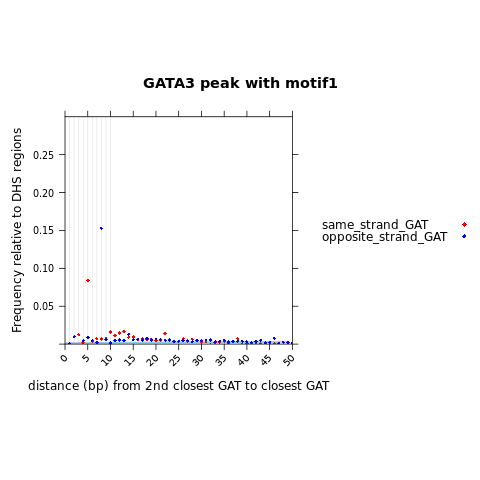

Figure 2: xy plot of GATA3 peak with motif1 relative to the DHS regions: 3mer structure

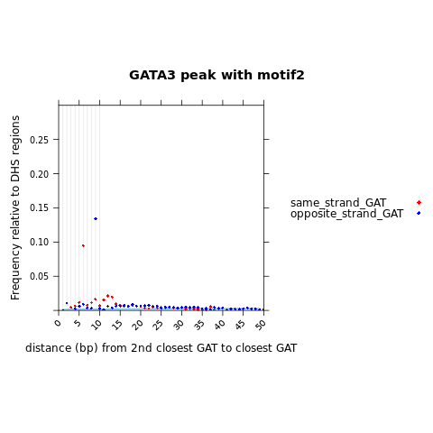

Figure 3: xy plot of GATA3 peak with motif2 relative to the DHS regions: 3mer structure

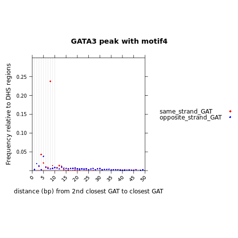

Figure 4: xy plot of GATA3 peak with motif4 relative to the DHS regions: 3mer structure

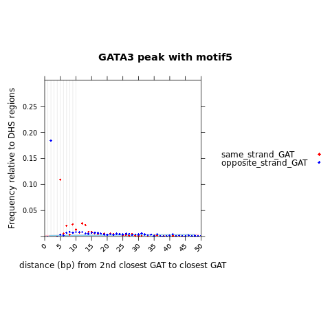

Figure 5: xy plot of GATA3 peak with motif5 relative to the DHS regions: 3mer structure

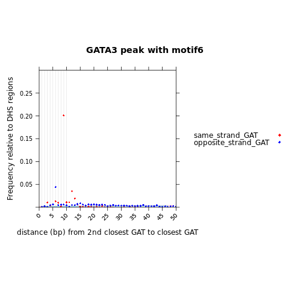

Figure 6: xy plot of GATA3 peak with motif6 relative to the DHS regions: 3mer structure

```r
 abs.dis dis strand_relationship  actual_freq actual_freq_DHS      rel_freq
1        1   1 opposite_strand_GAT 0.0008827896    0.0008383401  4.444953e-05
3        2   2 opposite_strand_GAT 0.0123590546    0.0026634763  9.695578e-03
5        3   3     same_strand_GAT 0.0286505357    0.0162428392  1.240770e-02
6        3   3 opposite_strand_GAT 0.0796516994    0.1027927204 -2.314102e-02
9        4   4     same_strand_GAT 0.0108743630    0.0088636999  2.010663e-03
10       4   4 opposite_strand_GAT 0.0085871353    0.0040607098  4.526426e-03
```

# 5 Automate analysis to go through the prioritized 3mers

In our previous analysis, we placed emphasis on certain 3-mers by assessing their enrichment in GATA3 peaks relative to DHS regions. This enrichment was determined by calculating the differences in cumulative distribution function (CDF) fractions at a specified “closed” distance (both 16bp and 20bp yield the same 3-mer cluster).

These prioritized 3mer includes “AAA” “TAA” “ATA” “TTA” “AAT” “TAT” “GAT” “ATT” “TTT” “ATC”.

Here, I want to  
1) Extract patterns from RSAT analysis that related to these 3mer combination and compare with the above analysis.

2. Automate customized analysis to go through the prioritized 3mers to measure the 2nd 3mer distance to the anchored 3mer.

First use GATA3 peaks with motif1 to do some test run, then perform the analysis to all 5 positive peak sets. Finally we want to apply to the peaks without motifs.

## 5.1 RSAT-dyad analysis – prioritized 3mer

### 5.1.1 Enrichment xy plot

Load the package, and the function to process the RSAT results file:

```r
library(Biostrings)
process_and_subset_RSAT <- function(file_path, pattern1, pattern2, number) {
  # Read the file
  input_data <- read.table(file_path, header = FALSE, sep = "\t")

  # Split the first column into components
  components_list <- strsplit(input_data$V1, "n\\{|\\}")

  processed_data <- data.frame(
    first = sapply(components_list, function(x) x[1]),
    dyad_distance = as.numeric(sapply(components_list, function(x) x[2])),
    second = sapply(components_list, function(x) x[3]),
    ratio = input_data$V8 # ratio
  )
  # patterns to DNAstring
  pattern1<-DNAString(pattern1)
  pattern2<-DNAString(pattern2)
  # Get the reverse complement of the patterns
  rc_pattern1 <- reverseComplement(pattern1)
  rc_pattern2 <- reverseComplement(pattern2)

  # Subset the dataframe based on the specified patterns and their reverse complements
  if (pattern1 == pattern2) {
    # Get the reverse complement of the patterns
    rc_pattern1 <- reverseComplement(pattern1)
    rc_pattern2 <- reverseComplement(pattern2)

    # Subset the dataframe based on the specified patterns and their reverse complements
    dyad_structure <- processed_data[grepl(pattern1, processed_data$first, ignore.case = TRUE) & grepl(pattern2, processed_data$second, ignore.case = TRUE), ]
    dyad_structure_rc <- processed_data[grepl(rc_pattern1, processed_data$first, ignore.case = TRUE) & grepl(rc_pattern2, processed_data$second, ignore.case = TRUE), ]

    output_data <- rbind(dyad_structure, dyad_structure_rc)
  } else {
    # If patterns are not the same, only subset based on pattern1 and pattern2
    output_data <- processed_data[grepl(pattern1, processed_data$first, ignore.case = TRUE) & grepl(pattern2, processed_data$second, ignore.case = TRUE), ]
  }

  # Order by descending ratio
  output_data <- output_data[order(-output_data$ratio), ]

  # Add the relative distance column
  output_data$relative_distance <- output_data$dyad_distance + number

  return(output_data)
}
```

In the provided function, **pattern1** represents the anchored dyad, **pattern2** denotes the other half dyad, and **number** signifies the user-defined distance (representing the relative separation between two zinc fingers, with “G” serving as the single resolution) when there is no spacing between each dyad.

For AAT and ATT, there is two possible relative “G/C”. One is (gat)AAT/ATT(atc), one is AAT(c)/(g)ATT.  
I have examined the Information Content (IC) in all Sequence logos of the Information Content Matrix, and examined the letter-probability matrix to determine which configiration is more common/more likely to observe.  
Overall, AAT(c)/(g)ATT have higher IC compared to (gat)AAT/ATT(atc).  
I will use AAT(c)/(g)ATT to anchor at the ‘G/C’ base for measuring the relative distance between the two zinc fingers.

I’ve created a file that simplifies the computation of the ‘number’ for any given pair of dyads. It operates by adding the corresponding numbers associated with the anchor (pattern1) or query (pattern2) pattern.

```r
#pattern_anchor_at_G_compute_dis.csv
read.csv('pattern_anchor_at_G_compute_dis.csv')
```

```
##    pattern identifier anchor query
## 1      GAT        GAT      3     0
## 2      ATC        ATC      1     2
## 3      ATA     (g)ATA      4    -1
## 4      TAT     TAT(c)      0     3
## 5      TTA    TTA(tc)     -1     4
## 6      TAA    (ga)TAA      5    -2
## 7      AAT     AAT(c)      0     3
## 8      ATT     (g)ATT      4    -1
## 9      AAA   (gat)AAA      6    -3
## 10     TTT   TTT(atc)     -2     5
## 11     AGA     AGA(t)      2     1
## 12     TCT     (a)TCT      2     1
## 13     TAG    (ga)TAG      5    -2
## 14     CTA    CTA(tc)     -1     4
```

```r
library(lattice)
library(latticeExtra)
library(Biostrings)

my_motifs = c("motif_1", "motif_4","motif_2", "motif_6", "motif_5")
Anchor_dyad = c("AAA", "TAA" ,"ATA" ,"TTA", "AAT", "TAT", "GAT", "ATT", "TTT", "ATC")
Query_dyad =c("AAA", "TAA" ,"ATA" ,"TTA", "AAT", "TAT", "GAT", "ATT", "TTT", "ATC")

compute_dis_df=read.csv('pattern_anchor_at_G_compute_dis.csv')

for (motif in my_motifs) {
  print(motif)
  rsat_results=paste0("GATA3_peak_161win_with_", motif, "_RSAT_dyad.txt")
  for (pattern1 in Anchor_dyad){
    print(pattern1)
    for (pattern2 in Query_dyad){
      print(pattern2)
      number1=compute_dis_df[compute_dis_df$pattern==pattern1, "anchor"] + compute_dis_df[compute_dis_df$pattern==pattern2, "query"]
      rc_pattern2=reverseComplement(DNAString(pattern2))
      print(rc_pattern2)
      number2=compute_dis_df[compute_dis_df$pattern==pattern1, "anchor"] + compute_dis_df[compute_dis_df$pattern==as.character(rc_pattern2), "query"]

      ss <- process_and_subset_RSAT(rsat_results, pattern1, pattern2, number1)
      os <- process_and_subset_RSAT(rsat_results, pattern1, rc_pattern2, number2)

      if(nrow(ss) > 0) {
                        ss$query_status <- paste0("same_strand_", pattern2)
                        } else {
                        ss <- data.frame(matrix(NA, ncol = ncol(ss), nrow = 1)) # Fill ss dataframe with NA values for all columns
                        colnames(ss) <- c("first", "dyad_distance", "second", "ratio","relative_distance")
                        ss$query_status <- paste0("same_strand_", pattern2)
                        }

      if(nrow(os) > 0) {
                        os$query_status <- paste0("opposite_strand_", pattern2)
                        } else {
                        os <- data.frame(matrix(NA, ncol = ncol(os), nrow = 1)) # Fill os dataframe with NA values for all columns
                        colnames(os) <- c("first", "dyad_distance", "second", "ratio","relative_distance")
                        os$query_status <- paste0("opposite_strand_", pattern2)
                        }

      df.plot=rbind(ss, os)
      df.plot$query_status = factor(df.plot$query_status, levels = c(paste0("same_strand_", pattern2), paste0("opposite_strand_", pattern2)))

      # xy plot
      pdf(paste0('test_xy_RSAT_dyad_closest_2nd_', pattern2, '_to_closest_1st_', pattern1, '_to_GATA3_pos_', motif, '_compare_to_DHS.pdf'), width=10,height=6)
      print(xyplot(ratio ~ relative_distance,
                   data = df.plot,
                   groups = query_status,
                   auto.key=list(space="right", points=TRUE),
                   aspect = 1,
                   xlim=c(0,30),
                   ylim=c(0, 500),
                   xlab = paste0("distance (bp) from 2nd closest ",pattern2, " to closest ", pattern1),
                   ylab="RSAT obs/exp Ratio",
                   main=paste0("GATA3 peak with ", motif),
                   between=list(y=1.0),
                   scales = list(x = list(rot = 45, at = seq(from = 0, to = 50, by = 5))),
                   par.settings = list(superpose.symbol = list(col=c("orange", "darkgreen"), pch=18, lwd=2), strip.background=list(col="grey85")),
                   panel = function(x,y,...) {panel.abline(v=c(seq(1, 10, 1)), col = "grey90")
                                              panel.xyplot(x, y,
                                                           col=c("orange","darkgreen"),
                                                           pch=18,
                                                           cex=0.6,...)
                                              #panel.barchart(x,y, horizontal = FALSE, col=c("red", "blue"), alpha=0.4)


                 }))
     dev.off()
    }
  }
}
```

test:

```r
library(lattice)
library(latticeExtra)
library(Biostrings)
my_motifs = c("motif_1")
Anchor_dyad = c("GAT")
Query_dyad =c("GAT")
compute_dis_df=read.csv('pattern_anchor_at_G_compute_dis.csv')

for (motif in my_motifs) {
  print(motif)
  rsat_results=paste0("GATA3_peak_161win_with_", motif, "_RSAT_dyad.txt")
  for (pattern1 in Anchor_dyad){
    print(pattern1)
    for (pattern2 in Query_dyad){
      print(pattern2)
      number1=compute_dis_df[compute_dis_df$pattern==pattern1, "anchor"] + compute_dis_df[compute_dis_df$pattern==pattern2, "query"]
      rc_pattern2=reverseComplement(DNAString(pattern2))
      print(rc_pattern2)
      number2=compute_dis_df[compute_dis_df$pattern==pattern1, "anchor"] + compute_dis_df[compute_dis_df$pattern==as.character(rc_pattern2), "query"]

      ss <- process_and_subset_RSAT(rsat_results, pattern1, pattern2, number1)
      os <- process_and_subset_RSAT(rsat_results, pattern1, rc_pattern2, number2)

      if(nrow(ss) > 0) {
                        ss$query_status <- paste0("same_strand_", pattern2)
                        } else {
                        ss <- data.frame(matrix(NA, ncol = ncol(ss), nrow = 1)) # Fill ss dataframe with NA values for all columns
                        colnames(ss) <- c("first", "dyad_distance", "second", "ratio","relative_distance")
                        ss$query_status <- paste0("same_strand_", pattern2)
                        }

      if(nrow(os) > 0) {
                        os$query_status <- paste0("opposite_strand_", pattern2)
                        } else {
                        os <- data.frame(matrix(NA, ncol = ncol(os), nrow = 1)) # Fill os dataframe with NA values for all columns
                        colnames(os) <- c("first", "dyad_distance", "second", "ratio","relative_distance")
                        os$query_status <- paste0("opposite_strand_", pattern2)
                        }

      df.plot=rbind(ss, os)
      df.plot$query_status = factor(df.plot$query_status, levels = c(paste0("same_strand_", pattern2), paste0("opposite_strand_", pattern2)))

      # xy plot
      pdf(paste0('test_xy_RSAT_dyad_closest_2nd_', pattern2, '_to_closest_1st_', pattern1, '_to_GATA3_pos_', motif, '_compare_to_DHS.pdf'), width=10,height=6)
      print(xyplot(ratio ~ relative_distance,
                   data = df.plot,
                   groups = query_status,
                   auto.key=list(space="right", points=TRUE),
                   aspect = 1,
                   xlim=c(0,30),
                   ylim=c(0, 500),
                   xlab = paste0("distance (bp) from 2nd closest ",pattern2, " to closest ", pattern1),
                   ylab="RSAT obs/exp Ratio",
                    main=paste0("GATA3 peak with ", motif),
                   between=list(y=1.0),
                   scales = list(x = list(rot = 45, at = seq(from = 0, to = 50, by = 5))),
                   par.settings = list(superpose.symbol = list(col=c("orange", "darkgreen"), pch=18, lwd=2), strip.background=list(col="grey85")),
                   panel = function(x,y,...) {panel.abline(v=c(seq(1, 10, 1)), col = "grey90")
                                              panel.xyplot(x, y,
                                                           col=c("orange","darkgreen"),
                                                           pch=18,
                                                           cex=0.6,...)
                                              #panel.barchart(x,y, horizontal = FALSE, col=c("red", "blue"), alpha=0.4)


                 }))
     dev.off()
    }
  }
}
```

test2:

```r
library(lattice)
library(latticeExtra)
library(Biostrings)
my_motifs = c("motif_1")
Anchor_dyad = c("TAA")
Query_dyad =c("AAA")
compute_dis_df=read.csv('pattern_anchor_at_G_compute_dis.csv')

for (motif in my_motifs) {
  print(motif)
  rsat_results=paste0("GATA3_peak_161win_with_", motif, "_RSAT_dyad.txt")
  for (pattern1 in Anchor_dyad){
    print(pattern1)
    for (pattern2 in Query_dyad){
      print(pattern2)
      number1=compute_dis_df[compute_dis_df$pattern==pattern1, "anchor"] + compute_dis_df[compute_dis_df$pattern==pattern2, "query"]
      rc_pattern2=reverseComplement(DNAString(pattern2))
      print(rc_pattern2)
      number2=compute_dis_df[compute_dis_df$pattern==pattern1, "anchor"] + compute_dis_df[compute_dis_df$pattern==as.character(rc_pattern2), "query"]

      ss <- process_and_subset_RSAT(rsat_results, pattern1, pattern2, number1)
      os <- process_and_subset_RSAT(rsat_results, pattern1, rc_pattern2, number2)

      if(nrow(ss) > 0) {
                        ss$query_status <- paste0("same_strand_", pattern2)
                        } else {
                        ss <- data.frame(matrix(NA, ncol = ncol(ss), nrow = 1)) # Fill ss dataframe with NA values for all columns
                        colnames(ss) <- c("first", "dyad_distance", "second", "ratio","relative_distance")
                        ss$query_status <- paste0("same_strand_", pattern2)
                        }

      if(nrow(os) > 0) {
                        os$query_status <- paste0("opposite_strand_", pattern2)
                        } else {
                        os <- data.frame(matrix(NA, ncol = ncol(os), nrow = 1)) # Fill os dataframe with NA values for all columns
                        colnames(os) <- c("first", "dyad_distance", "second", "ratio","relative_distance")
                        os$query_status <- paste0("opposite_strand_", pattern2)
                        }

      df.plot=rbind(ss, os)
      df.plot$query_status = factor(df.plot$query_status, levels = c(paste0("same_strand_", pattern2), paste0("opposite_strand_", pattern2)))

      # xy plot
      pdf(paste0('test_xy_RSAT_dyad_closest_2nd_', pattern2, '_to_closest_1st_', pattern1, '_to_GATA3_pos_', motif, '_compare_to_DHS.pdf'), width=10,height=6)
      print(xyplot(ratio ~ relative_distance,
                   data = df.plot,
                   groups = query_status,
                   auto.key=list(space="right", points=TRUE),
                   aspect = 1,
                   xlim=c(0,30),
                   ylim=c(0, 500),
                   xlab = paste0("distance (bp) from 2nd closest ",pattern2, " to closest ", pattern1),
                   ylab="RSAT obs/exp Ratio",
                    main=paste0("GATA3 peak with ", motif),
                   between=list(y=1.0),
                   scales = list(x = list(rot = 45, at = seq(from = 0, to = 50, by = 5))),
                   par.settings = list(superpose.symbol = list(col=c("orange", "darkgreen"), pch=18, lwd=2), strip.background=list(col="grey85")),
                   panel = function(x,y,...) {panel.abline(v=c(seq(1, 10, 1)), col = "grey90")
                                              panel.xyplot(x, y,
                                                           col=c("orange","darkgreen"),
                                                           pch=18,
                                                           cex=0.6,...)
                                              #panel.barchart(x,y, horizontal = FALSE, col=c("red", "blue"), alpha=0.4)


                 }))
     dev.off()
    }
  }
}
```

Anchor at one of the top 10 prioritized 3-mers, then query the remaining 10 3-mers on either the same strand or the opposite strand. This generates a 10x10=100 enrichment graph for each of the five peak data sets, resulting in a total of 500 enrichment graphs.

### 5.1.2 Ranking dyad-structure

Another method to identify the most enriched structure within each peak dataset is by ranking the files (from the 5 peak sets) based on the observed-to-expected (obs/exp) ratio. This allows us to determine which structural motif is enriched, followed by a search for the corresponding enrichment graph.

Files generated:  
GATA3_peak_161win_with_motif_1_RSAT_dyad.txt  
GATA3_peak_161win_with_motif_2_RSAT_dyad.txt  
GATA3_peak_161win_with_motif_4_RSAT_dyad.txt  
GATA3_peak_161win_with_motif_5_RSAT_dyad.txt  
GATA3_peak_161win_with_motif_6_RSAT_dyad.txt

**GATA3 peak with motif1**

```bash
cat GATA3_peak_161win_with_motif_1_RSAT_dyad.txt | sort -k8,8nr | head -3
```

```
## agan{0}taa   agan{0}taa|ttan{0}tct   0.0000096090146    5168   11.96 10  5178     432.28
## gatn{3}atc   gatn{3}atc|gatn{3}atc   0.0000716460535   12482   85.98 36  12518    145.17
## atan{2}atc   atan{2}atc|gatn{2}tat   0.0001616794646   10453  196.05 1460    11913     53.32
```

**GATA3 peak with motif2**

```bash
cat GATA3_peak_161win_with_motif_2_RSAT_dyad.txt | sort -k8,8nr | head -3
```

```
## agan{0}taa   agan{0}taa|ttan{0}tct   0.0000096090146    5367   11.05 15  5382     485.84
## gatn{4}atc   gatn{4}atc|gatn{4}atc   0.0000504302144   10109   55.31 57  10166    182.76
## atan{3}atc   atan{3}atc|gatn{3}tat   0.0001614461361    8061  178.78 812 8873      45.09
```

**GATA3 peak with motif4**

```bash
cat GATA3_peak_161win_with_motif_4_RSAT_dyad.txt | sort -k8,8nr | head -8
```

```
## agan{0}taa   agan{0}taa|ttan{0}tct   0.0000096090146    2635    6.31 0   2635     417.35
## atcn{5}atc   atcn{5}atc|gatn{5}gat   0.0001401253129    8136   86.45 3041    11177     94.11
## tagn{0}ata   tagn{0}ata|tatn{0}cta   0.0001101653224    4974   72.39 2520    7494      68.72
## gatn{6}ata   gatn{6}ata|tatn{6}atc   0.0001922430633    5856  117.34 2756    8612      49.91
## atan{0}gat   atan{0}gat|atcn{0}tat   0.0001759397041    5311  115.60 2653    7964      45.94
## atan{4}gat   atan{4}gat|atcn{4}tat   0.0001505921639    4145   93.97 2862    7007      44.11
## gatn{2}ata   gatn{2}ata|tatn{2}atc   0.0001517807219    4287   97.37 2333    6620      44.03
## atcn{1}atc   atcn{1}atc|gatn{1}gat   0.0001617727236    4361  105.00 2663    7024      41.53
```

**GATA3 peak with motif5**

```bash
cat GATA3_peak_161win_with_motif_5_RSAT_dyad.txt | sort -k8,8nr | head -10
```

```
## agan{0}taa   agan{0}taa|ttan{0}tct   0.0000096090146    1460    4.15 0   1460     351.92
## atcn{1}gat   atcn{1}gat|atcn{1}gat   0.0000365557250    4232   15.61 14  4246     271.11
## atcn{2}ata   atcn{2}ata|tatn{2}gat   0.0001323956841    3042   55.76 429 3471      54.55
## gatn{0}aac   gatn{0}aac|gttn{0}atc   0.0000457443231     612   19.75 0   612   30.99
## ctgn{0}ata   ctgn{0}ata|tatn{0}cag   0.0001502254396    1839   64.86 5   1844      28.35
## atcn{0}tga   atcn{0}tga|tcan{0}gat   0.0004057440254    4520  175.18 50  4570      25.80
## gatn{0}aaa   gatn{0}aaa|tttn{0}atc   0.0001042104402    1134   44.99 0   1134      25.20
## atcn{0}aga   atcn{0}aga|tctn{0}gat   0.0004149470253    4458  179.15 40  4498      24.88
## atcn{3}taa   atcn{3}taa|ttan{3}gat   0.0001898551128    1853   79.23 91  1944      23.39
## aatn{2}gat   aatn{2}gat|atcn{2}att   0.0002558550032    2514  107.76 354 2868      23.33
```

```bash
awk -F'\t' '$1 ~ /^gat.*gat/' GATA3_peak_161win_with_motif_5_RSAT_dyad.txt | head
awk -F'\t' '$1 ~ /^atc.*atc/' GATA3_peak_161win_with_motif_5_RSAT_dyad.txt | head
echo ""
awk -F'\t' '$1 ~ /^gat.*atc/' GATA3_peak_161win_with_motif_5_RSAT_dyad.txt | head

echo ""
awk -F'\t' '$1 ~ /^atc.*gat/' GATA3_peak_161win_with_motif_5_RSAT_dyad.txt | head
```

```
## atcn{2}atc   atcn{2}atc|gatn{2}gat   0.0001743278582    1580   73.43 190 1770      21.52
## atcn{9}atc   atcn{9}atc|gatn{9}gat   0.0002062495205     684   80.71 39  723    8.47
## atcn{6}atc   atcn{6}atc|gatn{6}gat   0.0001786128314     568   72.21 29  597    7.87
## atcn{10}atc  atcn{10}atc|gatn{10}gat 0.0002081405868     567   80.51 34  601    7.04
## atcn{4}atc   atcn{4}atc|gatn{4}gat   0.0001842588721     523   76.09 37  560    6.87
## atcn{7}atc   atcn{7}atc|gatn{7}gat   0.0001966917141     445   78.65 32  477    5.66
## atcn{11}atc  atcn{11}atc|gatn{11}gat 0.0001856378756     413   71.03 26  439    5.81
## atcn{12}atc  atcn{12}atc|gatn{12}gat 0.0001884293340     393   71.25 26  419    5.52
## atcn{15}atc  atcn{15}atc|gatn{15}gat 0.0002001648218     389   73.16 18  407    5.32
## atcn{14}atc  atcn{14}atc|gatn{14}gat 0.0001838280257     375   67.98 56  431    5.52
##
## gatn{5}atc   gatn{5}atc|gatn{5}atc   0.0000883000715     329   36.10 1   330    9.11
## gatn{3}atc   gatn{3}atc|gatn{3}atc   0.0000716460535     239   29.90 6   245    7.99
## gatn{0}atc   gatn{0}atc|gatn{0}atc   0.0000515638671     228   22.26 0   228   10.24
## gatn{8}atc   gatn{8}atc|gatn{8}atc   0.0000899257860     216   35.58 2   218    6.07
## gatn{11}atc  gatn{11}atc|gatn{11}atc 0.0000932630475     214   35.68 1   215    6.00
## gatn{6}atc   gatn{6}atc|gatn{6}atc   0.0000971154028     213   39.26 2   215    5.43
## gatn{10}atc  gatn{10}atc|gatn{10}atc 0.0000987860472     209   38.21 0   209    5.47
## gatn{2}atc   gatn{2}atc|gatn{2}atc   0.0000878513418     208   37.00 0   208    5.62
## gatn{7}atc   gatn{7}atc|gatn{7}atc   0.0000847463572     192   33.89 0   192    5.67
## gatn{12}atc  gatn{12}atc|gatn{12}atc 0.0000888395037     186   33.59 3   189    5.54
##
## atcn{1}gat   atcn{1}gat|atcn{1}gat   0.0000365557250    4232   15.61 14  4246     271.11
## atcn{8}gat   atcn{8}gat|atcn{8}gat   0.0000890597270     315   35.23 5   320    8.94
## atcn{10}gat  atcn{10}gat|atcn{10}gat 0.0000804379701     250   31.11 3   253    8.03
## atcn{6}gat   atcn{6}gat|atcn{6}gat   0.0000802195944     243   32.43 3   246    7.49
## atcn{14}gat  atcn{14}gat|atcn{14}gat 0.0000920659368     237   34.05 3   240    6.96
## atcn{13}gat  atcn{13}gat|atcn{13}gat 0.0000915682647     232   34.24 2   234    6.77
## atcn{7}gat   atcn{7}gat|atcn{7}gat   0.0000795928625     222   31.83 4   226    6.98
## atcn{11}gat  atcn{11}gat|atcn{11}gat 0.0000917826817     219   35.12 4   223    6.24
## atcn{18}gat  atcn{18}gat|atcn{18}gat 0.0000928758991     201   32.74 1   202    6.14
## atcn{15}gat  atcn{15}gat|atcn{15}gat 0.0000847558549     185   30.98 1   186    5.97
```

**GATA3 peak with motif6**

```bash
cat GATA3_peak_161win_with_motif_6_RSAT_dyad.txt | sort -k8,8nr | head -3
```

```
## agan{0}taa   agan{0}taa|ttan{0}tct   0.0000096090146    2445    5.38 2   2447     454.40
## atcn{6}atc   atcn{6}atc|gatn{6}gat   0.0001786128314    3871   93.56 216 4087      41.37
## gatn{7}ata   gatn{7}ata|tatn{7}atc   0.0001561795197    3011   80.92 119 3130      37.21
```

In the above 5 GATA3 peak data sets, it seems that **AGA-TAA**, **GAT-ATC**, **ATA-ATC**, **ATC-ATC**, **TAG-ATA**, **ATC-GAT**, **ATC-ATA** and **GAT-ATA** are enriched in GATA3 peaks contains GATA3 motifs.

#### 5.1.2.1 AGA-TAA

Unfortunately, **AGA** is not included in our prioritized list, but it is ranked just after TTT/AAA. Therefore, we can include an analysis of this 3-mer here.  
And in our customized analysis, we might also include AGA/TCT to our prioritized 3mer list.

```
## [1] "motif_1"
## [1] "AGA"
## [1] "TAA"
## 3-letter DNAString object
## seq: TTA
```

```
## [1] "motif_4"
## [1] "AGA"
## [1] "TAA"
## 3-letter DNAString object
## seq: TTA
```

```
## [1] "motif_2"
## [1] "AGA"
## [1] "TAA"
## 3-letter DNAString object
## seq: TTA
```

```
## [1] "motif_6"
## [1] "AGA"
## [1] "TAA"
## 3-letter DNAString object
## seq: TTA
```

```
## [1] "motif_5"
## [1] "AGA"
## [1] "TAA"
## 3-letter DNAString object
## seq: TTA
```

[figure not shown]

Figure 7: xy plot of rsat analysis for GATA3 peak with motif4: 3mer structure

```r
library(lattice)
library(latticeExtra)
library(Biostrings)
my_motifs = c("motif_1", "motif_4","motif_2", "motif_6", "motif_5")
Anchor_dyad = c("AGA")
Query_dyad =c("TAA")
compute_dis_df=read.csv('pattern_anchor_at_G_compute_dis.csv')

for (motif in my_motifs) {
  print(motif)
  rsat_results=paste0("GATA3_peak_161win_with_", motif, "_RSAT_dyad.txt")
  for (pattern1 in Anchor_dyad){
    print(pattern1)
    for (pattern2 in Query_dyad){
      print(pattern2)
      number1=compute_dis_df[compute_dis_df$pattern==pattern1, "anchor"] + compute_dis_df[compute_dis_df$pattern==pattern2, "query"]
      rc_pattern2=reverseComplement(DNAString(pattern2))
      print(rc_pattern2)
      number2=compute_dis_df[compute_dis_df$pattern==pattern1, "anchor"] + compute_dis_df[compute_dis_df$pattern==as.character(rc_pattern2), "query"]

      ss <- process_and_subset_RSAT(rsat_results, pattern1, pattern2, number1)
      os <- process_and_subset_RSAT(rsat_results, pattern1, rc_pattern2, number2)

      if(nrow(ss) > 0) {
                        ss$query_status <- paste0("same_strand_", pattern2)
                        } else {
                        ss <- data.frame(matrix(NA, ncol = ncol(ss), nrow = 1)) # Fill ss dataframe with NA values for all columns
                        colnames(ss) <- c("first", "dyad_distance", "second", "ratio","relative_distance")
                        ss$query_status <- paste0("same_strand_", pattern2)
                        }

      if(nrow(os) > 0) {
                        os$query_status <- paste0("opposite_strand_", pattern2)
                        } else {
                        os <- data.frame(matrix(NA, ncol = ncol(os), nrow = 1)) # Fill os dataframe with NA values for all columns
                        colnames(os) <- c("first", "dyad_distance", "second", "ratio","relative_distance")
                        os$query_status <- paste0("opposite_strand_", pattern2)
                        }

      df.plot=rbind(ss, os)
      df.plot$query_status = factor(df.plot$query_status, levels = c(paste0("same_strand_", pattern2), paste0("opposite_strand_", pattern2)))

      # xy plot
      pdf(paste0('xy_RSAT_dyad_closest_2nd_', pattern2, '_to_closest_1st_', pattern1, '_to_GATA3_pos_', motif, '_compare_to_DHS.pdf'), width=10,height=6)
      print(xyplot(ratio ~ relative_distance,
                   data = df.plot,
                   groups = query_status,
                   auto.key=list(space="right", points=TRUE),
                   aspect = 1,
                   xlim=c(-1,30),
                   ylim=c(0, 500),
                   xlab = paste0("distance (bp) from 2nd closest ",pattern2, " to closest ", pattern1),
                   ylab="RSAT obs/exp Ratio",
                    main=paste0("GATA3 peak with ", motif),
                   between=list(y=1.0),
                   scales = list(x = list(rot = 45, at = seq(from = 0, to = 50, by = 5))),
                   par.settings = list(superpose.symbol = list(col=c("orange", "darkgreen"), pch=18, lwd=2), strip.background=list(col="grey85")),
                   panel = function(x,y,...) {panel.abline(v=c(seq(1, 10, 1)), col = "grey90")
                                              panel.xyplot(x, y,
                                                           col=c("orange","darkgreen"),
                                                           pch=18,
                                                           cex=0.6,...)
                                              #panel.barchart(x,y, horizontal = FALSE, col=c("red", "blue"), alpha=0.4)


                 }))
     dev.off()
    }
  }
}
```

All enrichment graphs show enrichment of a dyad structure with AGA 6bp distal from the opposite strand TAA, which is a [AGA][TTA]TC. With a relative distance from G to C being 6bp.

We did not observe enrichment at a relative distance of 0 between AGA and TAA on the same strand. This is because a relative distance of 0 between two zinc fingers implies that only one zinc finger is binding in that location, indicating the absence of a dyad structure. Similarly, when we did not observe enrichment for the AGATAA structure in our graph, it’s because AGATAA is considered a single binding site, rather than two separate motifs.

#### 5.1.2.2 GAT-ATC

```r
library(lattice)
library(latticeExtra)
library(Biostrings)
my_motifs = c("motif_1", "motif_4","motif_2", "motif_6", "motif_5")
Anchor_dyad = c("GAT")
Query_dyad =c("ATC")
compute_dis_df=read.csv('pattern_anchor_at_G_compute_dis.csv')

for (motif in my_motifs) {
  print(motif)
  rsat_results=paste0("GATA3_peak_161win_with_", motif, "_RSAT_dyad.txt")
  for (pattern1 in Anchor_dyad){
    print(pattern1)
    for (pattern2 in Query_dyad){
      print(pattern2)
      number1=compute_dis_df[compute_dis_df$pattern==pattern1, "anchor"] + compute_dis_df[compute_dis_df$pattern==pattern2, "query"]
      rc_pattern2=reverseComplement(DNAString(pattern2))
      print(rc_pattern2)
      number2=compute_dis_df[compute_dis_df$pattern==pattern1, "anchor"] + compute_dis_df[compute_dis_df$pattern==as.character(rc_pattern2), "query"]

      ss <- process_and_subset_RSAT(rsat_results, pattern1, pattern2, number1)
      os <- process_and_subset_RSAT(rsat_results, pattern1, rc_pattern2, number2)

      if(nrow(ss) > 0) {
                        ss$query_status <- paste0("same_strand_", pattern2)
                        } else {
                        ss <- data.frame(matrix(NA, ncol = ncol(ss), nrow = 1)) # Fill ss dataframe with NA values for all columns
                        colnames(ss) <- c("first", "dyad_distance", "second", "ratio","relative_distance")
                        ss$query_status <- paste0("same_strand_", pattern2)
                        }

      if(nrow(os) > 0) {
                        os$query_status <- paste0("opposite_strand_", pattern2)
                        } else {
                        os <- data.frame(matrix(NA, ncol = ncol(os), nrow = 1)) # Fill os dataframe with NA values for all columns
                        colnames(os) <- c("first", "dyad_distance", "second", "ratio","relative_distance")
                        os$query_status <- paste0("opposite_strand_", pattern2)
                        }

      df.plot=rbind(ss, os)
      df.plot$query_status = factor(df.plot$query_status, levels = c(paste0("same_strand_", pattern2), paste0("opposite_strand_", pattern2)))

      # xy plot
      png(paste0('xy_RSAT_dyad_closest_2nd_', pattern2, '_to_closest_1st_', pattern1, '_to_GATA3_pos_', motif, '_compare_to_DHS.png'))
      print(xyplot(ratio ~ relative_distance,
                   data = df.plot,
                   groups = query_status,
                   auto.key=list(space="right", points=TRUE),
                   aspect = 1,
                   xlim=c(-1,30),
                   ylim=c(0, 500),
                   xlab = paste0("distance (bp) from 2nd closest ",pattern2, " to closest ", pattern1),
                   ylab="RSAT obs/exp Ratio",
                    main=paste0("GATA3 peak with ", motif),
                   between=list(y=1.0),
                   scales = list(x = list(rot = 45, at = seq(from = 0, to = 50, by = 5))),
                   par.settings = list(superpose.symbol = list(col=c("orange", "darkgreen"), pch=18, lwd=2), strip.background=list(col="grey85")),
                   panel = function(x,y,...) {panel.abline(v=c(seq(1, 10, 1)), col = "grey90")
                                              panel.xyplot(x, y,
                                                           col=c("orange","darkgreen"),
                                                           pch=18,
                                                           cex=0.6,...)
                                              #panel.barchart(x,y, horizontal = FALSE, col=c("red", "blue"), alpha=0.4)


                 }))
     dev.off()
    }
  }
}
```

```
## [1] "motif_1"
## [1] "GAT"
## [1] "ATC"
## 3-letter DNAString object
## seq: GAT
```

```
## [1] "motif_4"
## [1] "GAT"
## [1] "ATC"
## 3-letter DNAString object
## seq: GAT
```

```
## [1] "motif_2"
## [1] "GAT"
## [1] "ATC"
## 3-letter DNAString object
## seq: GAT
```

```
## [1] "motif_6"
## [1] "GAT"
## [1] "ATC"
## 3-letter DNAString object
## seq: GAT
```

```
## [1] "motif_5"
## [1] "GAT"
## [1] "ATC"
## 3-letter DNAString object
## seq: GAT
```

**GATA3 peak with motif1**

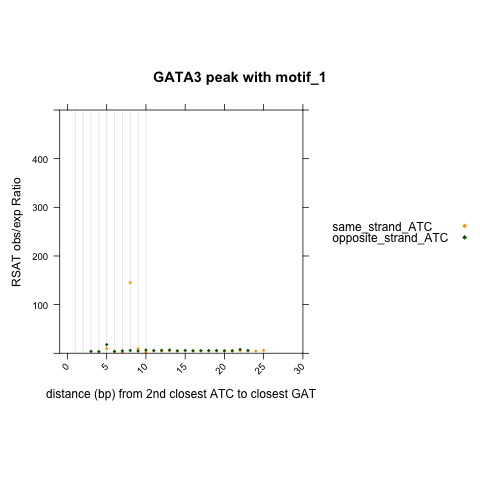

Figure 8: xy plot of rsat analysis for GATA3 peak with motif1: 3mer structure

For GATA3 peaks with motif1, we have seen an enriched dyad structure of a GAT with 8bp relative distance to its same strand ATC.  
This is same as the RSAT defined GATn{3}ATC which rank as second highest ratio. And also match the motif1 PWMs/seqlogo.

**GATA3 peak with motif2**

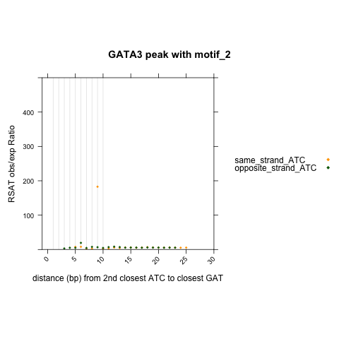

Figure 9: xy plot of rsat analysis for GATA3 peak with motif2: 3mer structure

For GATA3 peaks with motif2, we have seen an enriched dyad structure of a GAT with 9bp relative distance to its same strand ATC.  
This is same as the RSAT defined GATn{4}ATC which rank as second highest ratio. And also match the motif2 PWMs/seqlogo.

**GATA3 peak with motif4**

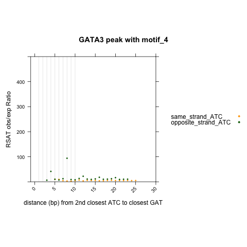

Figure 10: xy plot of rsat analysis for GATA3 peak with motif4: 3mer structure

For GATA3 peaks with motif4, we have seen an enriched dyad structure of a GAT with 8bp relative distance to its opposite strand ATC (same as the same strand GAT).  
This is same as the RSAT defined atcn{5}atc/gatn{5}gat which rank as second highest ratio. And also match the motif4 PWMs/seqlogo.

**GATA3 peak with motif6**

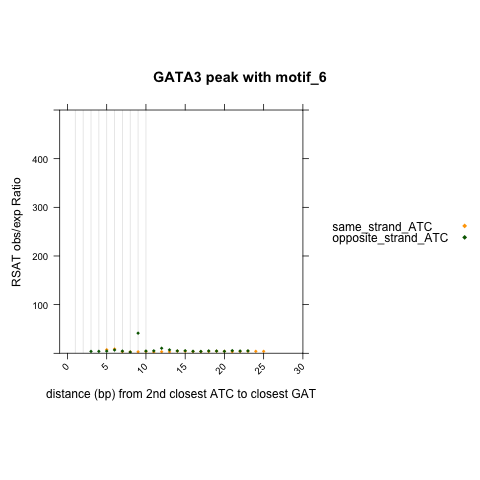

Figure 11: xy plot of rsat analysis for GATA3 peak with motif6: 3mer structure

For GATA3 peaks with motif6, we have seen an enriched dyad structure of a GAT with 9bp relative distance to its opposite strand ATC.  
This is same as the RSAT defined atcn{6}atc|gatn{6}gat which rank as second highest ratio. And also match the motif2 PWMs/seqlogo.

**GATA3 peak with motif5**

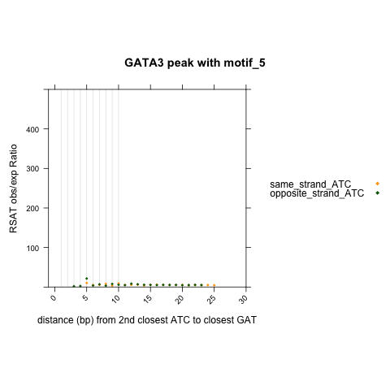

Figure 12: xy plot of rsat analysis for GATA3 peak with motif5: 3mer structure

For GATA3 peaks with motif5, we did not see a very enriched dyad structure for GAT relative to +/- ATC. The relative distance at 5bp may or may not be enriched (afterall the ratio seems to be below 25). This is expected, because motif5 has a specific structure of ATCn{1}GAT, which ranked as 2nd highest ratio in the rsat results. This structure is different than GAT relative to +/- ATC.

#### 5.1.2.3 ATC-GAT

```r
library(lattice)
library(latticeExtra)
library(Biostrings)
my_motifs = c("motif_1", "motif_4","motif_2", "motif_6", "motif_5")
Anchor_dyad = c("ATC")
Query_dyad =c("GAT")
compute_dis_df=read.csv('pattern_anchor_at_G_compute_dis.csv')

for (motif in my_motifs) {
  print(motif)
  rsat_results=paste0("GATA3_peak_161win_with_", motif, "_RSAT_dyad.txt")
  for (pattern1 in Anchor_dyad){
    print(pattern1)
    for (pattern2 in Query_dyad){
      print(pattern2)
      number1=compute_dis_df[compute_dis_df$pattern==pattern1, "anchor"] + compute_dis_df[compute_dis_df$pattern==pattern2, "query"]
      rc_pattern2=reverseComplement(DNAString(pattern2))
      print(rc_pattern2)
      number2=compute_dis_df[compute_dis_df$pattern==pattern1, "anchor"] + compute_dis_df[compute_dis_df$pattern==as.character(rc_pattern2), "query"]

      ss <- process_and_subset_RSAT(rsat_results, pattern1, pattern2, number1)
      os <- process_and_subset_RSAT(rsat_results, pattern1, rc_pattern2, number2)

      if(nrow(ss) > 0) {
                        ss$query_status <- paste0("same_strand_", pattern2)
                        } else {
                        ss <- data.frame(matrix(NA, ncol = ncol(ss), nrow = 1)) # Fill ss dataframe with NA values for all columns
                        colnames(ss) <- c("first", "dyad_distance", "second", "ratio","relative_distance")
                        ss$query_status <- paste0("same_strand_", pattern2)
                        }

      if(nrow(os) > 0) {
                        os$query_status <- paste0("opposite_strand_", pattern2)
                        } else {
                        os <- data.frame(matrix(NA, ncol = ncol(os), nrow = 1)) # Fill os dataframe with NA values for all columns
                        colnames(os) <- c("first", "dyad_distance", "second", "ratio","relative_distance")
                        os$query_status <- paste0("opposite_strand_", pattern2)
                        }

      df.plot=rbind(ss, os)
      df.plot$query_status = factor(df.plot$query_status, levels = c(paste0("same_strand_", pattern2), paste0("opposite_strand_", pattern2)))

      # xy plot
      png(paste0('xy_RSAT_dyad_closest_2nd_', pattern2, '_to_closest_1st_', pattern1, '_to_GATA3_pos_', motif, '_compare_to_DHS.png'))
      print(xyplot(ratio ~ relative_distance,
                   data = df.plot,
                   groups = query_status,
                   auto.key=list(space="right", points=TRUE),
                   aspect = 1,
                   xlim=c(-1,30),
                   ylim=c(0, 500),
                   xlab = paste0("distance (bp) from 2nd closest ",pattern2, " to closest ", pattern1),
                   ylab="RSAT obs/exp Ratio",
                    main=paste0("GATA3 peak with ", motif),
                   between=list(y=1.0),
                   scales = list(x = list(rot = 45, at = seq(from = 0, to = 50, by = 5))),
                   par.settings = list(superpose.symbol = list(col=c("orange", "darkgreen"), pch=18, lwd=2), strip.background=list(col="grey85")),
                   panel = function(x,y,...) {panel.abline(v=c(seq(1, 10, 1)), col = "grey90")
                                              panel.xyplot(x, y,
                                                           col=c("orange","darkgreen"),
                                                           pch=18,
                                                           cex=0.6,...)
                                              #panel.barchart(x,y, horizontal = FALSE, col=c("red", "blue"), alpha=0.4)


                 }))
     dev.off()
    }
  }
}
```

```
## [1] "motif_1"
## [1] "ATC"
## [1] "GAT"
## 3-letter DNAString object
## seq: ATC
```

```
## [1] "motif_4"
## [1] "ATC"
## [1] "GAT"
## 3-letter DNAString object
## seq: ATC
```

```
## [1] "motif_2"
## [1] "ATC"
## [1] "GAT"
## 3-letter DNAString object
## seq: ATC
```

```
## [1] "motif_6"
## [1] "ATC"
## [1] "GAT"
## 3-letter DNAString object
## seq: ATC
```

```
## [1] "motif_5"
## [1] "ATC"
## [1] "GAT"
## 3-letter DNAString object
## seq: ATC
```

**GATA3 peak with motif5**

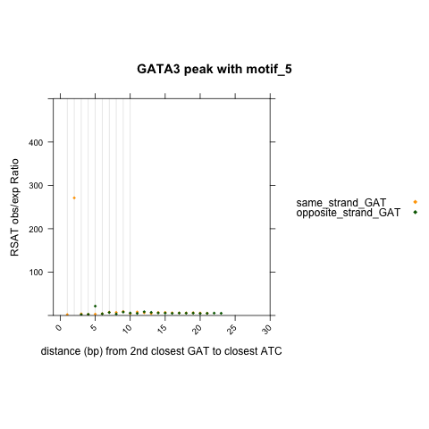

This is same as the RSAT defined atcn{1}gat which rank as second highest ratio. And also match the motif5 PWMs/seqlogo.

#### 5.1.2.4 ATA-ATC

```
## [1] "motif_1"
## [1] "ATA"
## [1] "ATC"
## 3-letter DNAString object
## seq: GAT
```

```
## [1] "motif_4"
## [1] "ATA"
## [1] "ATC"
## 3-letter DNAString object
## seq: GAT
```

```
## [1] "motif_2"
## [1] "ATA"
## [1] "ATC"
## 3-letter DNAString object
## seq: GAT
```

```
## [1] "motif_6"
## [1] "ATA"
## [1] "ATC"
## 3-letter DNAString object
## seq: GAT
```

```
## [1] "motif_5"
## [1] "ATA"
## [1] "ATC"
## 3-letter DNAString object
## seq: GAT
```

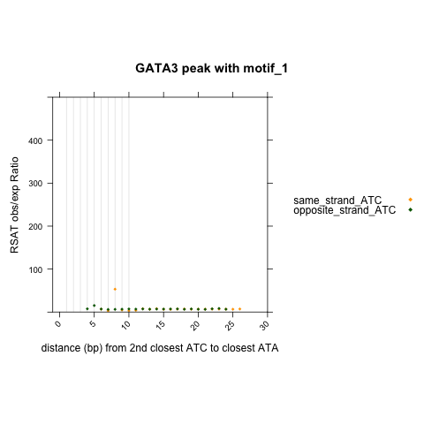

Figure 14: xy plot of rsat analysis for GATA3 peak with motif12456: 3mer structure

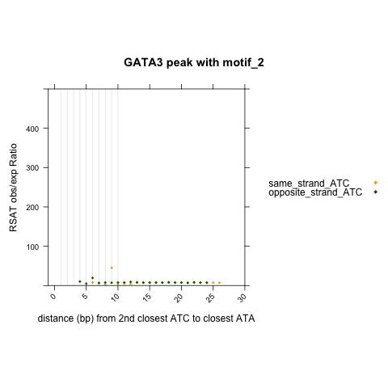

Figure 15: xy plot of rsat analysis for GATA3 peak with motif12456: 3mer structure

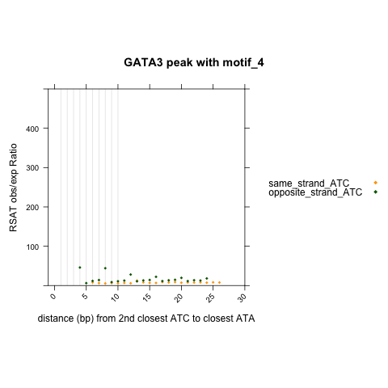

Figure 16: xy plot of rsat analysis for GATA3 peak with motif12456: 3mer structure

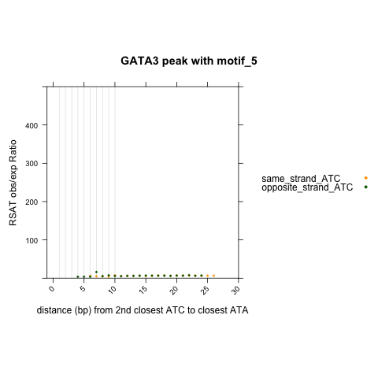

Figure 17: xy plot of rsat analysis for GATA3 peak with motif12456: 3mer structure

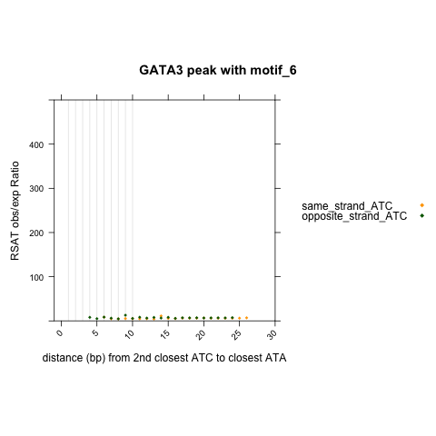

Figure 18: xy plot of rsat analysis for GATA3 peak with motif12456: 3mer structure

```r
library(lattice)
library(latticeExtra)
library(Biostrings)
my_motifs = c("motif_1", "motif_4","motif_2", "motif_6", "motif_5")
Anchor_dyad = c("ATA")
Query_dyad =c("ATC")
compute_dis_df=read.csv('pattern_anchor_at_G_compute_dis.csv')

for (motif in my_motifs) {
  print(motif)
  rsat_results=paste0("GATA3_peak_161win_with_", motif, "_RSAT_dyad.txt")
  for (pattern1 in Anchor_dyad){
    print(pattern1)
    for (pattern2 in Query_dyad){
      print(pattern2)
      number1=compute_dis_df[compute_dis_df$pattern==pattern1, "anchor"] + compute_dis_df[compute_dis_df$pattern==pattern2, "query"]
      rc_pattern2=reverseComplement(DNAString(pattern2))
      print(rc_pattern2)
      number2=compute_dis_df[compute_dis_df$pattern==pattern1, "anchor"] + compute_dis_df[compute_dis_df$pattern==as.character(rc_pattern2), "query"]

      ss <- process_and_subset_RSAT(rsat_results, pattern1, pattern2, number1)
      os <- process_and_subset_RSAT(rsat_results, pattern1, rc_pattern2, number2)

      if(nrow(ss) > 0) {
                        ss$query_status <- paste0("same_strand_", pattern2)
                        } else {
                        ss <- data.frame(matrix(NA, ncol = ncol(ss), nrow = 1)) # Fill ss dataframe with NA values for all columns
                        colnames(ss) <- c("first", "dyad_distance", "second", "ratio","relative_distance")
                        ss$query_status <- paste0("same_strand_", pattern2)
                        }

      if(nrow(os) > 0) {
                        os$query_status <- paste0("opposite_strand_", pattern2)
                        } else {
                        os <- data.frame(matrix(NA, ncol = ncol(os), nrow = 1)) # Fill os dataframe with NA values for all columns
                        colnames(os) <- c("first", "dyad_distance", "second", "ratio","relative_distance")
                        os$query_status <- paste0("opposite_strand_", pattern2)
                        }

      df.plot=rbind(ss, os)
      df.plot$query_status = factor(df.plot$query_status, levels = c(paste0("same_strand_", pattern2), paste0("opposite_strand_", pattern2)))

      # xy plot
      png(paste0('xy_RSAT_dyad_closest_2nd_', pattern2, '_to_closest_1st_', pattern1, '_to_GATA3_pos_', motif, '_compare_to_DHS.png'))
      print(xyplot(ratio ~ relative_distance,
                   data = df.plot,
                   groups = query_status,
                   auto.key=list(space="right", points=TRUE),
                   aspect = 1,
                   xlim=c(-1,30),
                   ylim=c(0, 500),
                   xlab = paste0("distance (bp) from 2nd closest ",pattern2, " to closest ", pattern1),
                   ylab="RSAT obs/exp Ratio",
                    main=paste0("GATA3 peak with ", motif),
                   between=list(y=1.0),
                   scales = list(x = list(rot = 45, at = seq(from = 0, to = 50, by = 5))),
                   par.settings = list(superpose.symbol = list(col=c("orange", "darkgreen"), pch=18, lwd=2), strip.background=list(col="grey85")),
                   panel = function(x,y,...) {panel.abline(v=c(seq(1, 10, 1)), col = "grey90")
                                              panel.xyplot(x, y,
                                                           col=c("orange","darkgreen"),
                                                           pch=18,
                                                           cex=0.6,...)
                                              #panel.barchart(x,y, horizontal = FALSE, col=c("red", "blue"), alpha=0.4)


                 }))
     dev.off()
    }
  }
}
```

It is clear in the enrichment graph that GATA3 peaks with motif1 has an enriched dyad structure of ATAn{2}ATC (relative distance of two zinc fingers is 8bp); GATA3 peaks with motif2 has an enriched dyad structure of ATAn{3}ATC (relative distance of two zinc finger is 9bp).  
For GATA3 peaks with motif4, ATAn{0}GAT and ATA{4}GAT are enriched. The relative distances of two zinc fingers are at 4bp and 8bp.  
No remarkable enrichment of dyad structure related to ATA and ATC for GATA3 peaks with motif5 and motif6.

#### 5.1.2.5 ATC-ATC

Notice that this is anchoring at ATC and looking for ATC on same strand or opposite strand.

```
## [1] "motif_1"
## [1] "ATC"
## [1] "ATC"
## 3-letter DNAString object
## seq: GAT
```

```
## [1] "motif_4"
## [1] "ATC"
## [1] "ATC"
## 3-letter DNAString object
## seq: GAT
```

```
## [1] "motif_2"
## [1] "ATC"
## [1] "ATC"
## 3-letter DNAString object
## seq: GAT
```

```
## [1] "motif_6"
## [1] "ATC"
## [1] "ATC"
## 3-letter DNAString object
## seq: GAT
```

```
## [1] "motif_5"
## [1] "ATC"
## [1] "ATC"
## 3-letter DNAString object
## seq: GAT
```

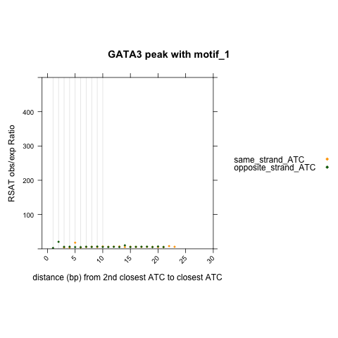

Figure 19: xy plot of rsat analysis for GATA3 peak with motif12456: 3mer structure

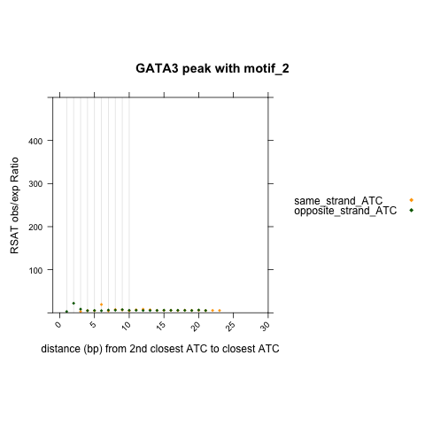

Figure 20: xy plot of rsat analysis for GATA3 peak with motif12456: 3mer structure

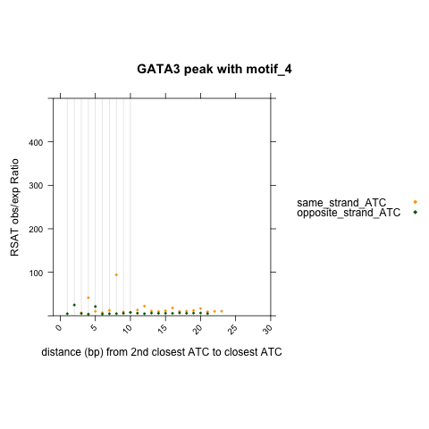

Figure 21: xy plot of rsat analysis for GATA3 peak with motif12456: 3mer structure

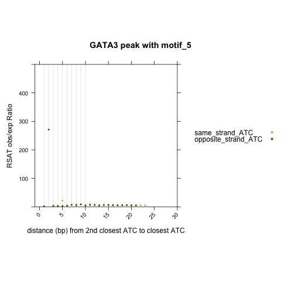

Figure 22: xy plot of rsat analysis for GATA3 peak with motif12456: 3mer structure

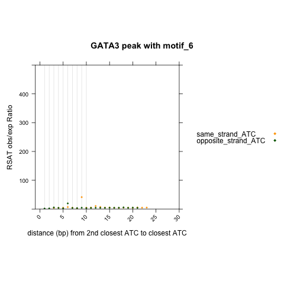

Figure 23: xy plot of rsat analysis for GATA3 peak with motif12456: 3mer structure

```r
library(lattice)
library(latticeExtra)
library(Biostrings)
my_motifs = c("motif_1", "motif_4","motif_2", "motif_6", "motif_5")
Anchor_dyad = c("ATC")
Query_dyad =c("ATC")
compute_dis_df=read.csv('pattern_anchor_at_G_compute_dis.csv')

for (motif in my_motifs) {
  print(motif)
  rsat_results=paste0("GATA3_peak_161win_with_", motif, "_RSAT_dyad.txt")
  for (pattern1 in Anchor_dyad){
    print(pattern1)
    for (pattern2 in Query_dyad){
      print(pattern2)
      number1=compute_dis_df[compute_dis_df$pattern==pattern1, "anchor"] + compute_dis_df[compute_dis_df$pattern==pattern2, "query"]
      rc_pattern2=reverseComplement(DNAString(pattern2))
      print(rc_pattern2)
      number2=compute_dis_df[compute_dis_df$pattern==pattern1, "anchor"] + compute_dis_df[compute_dis_df$pattern==as.character(rc_pattern2), "query"]

      ss <- process_and_subset_RSAT(rsat_results, pattern1, pattern2, number1)
      os <- process_and_subset_RSAT(rsat_results, pattern1, rc_pattern2, number2)

      if(nrow(ss) > 0) {
                        ss$query_status <- paste0("same_strand_", pattern2)
                        } else {
                        ss <- data.frame(matrix(NA, ncol = ncol(ss), nrow = 1)) # Fill ss dataframe with NA values for all columns
                        colnames(ss) <- c("first", "dyad_distance", "second", "ratio","relative_distance")
                        ss$query_status <- paste0("same_strand_", pattern2)
                        }

      if(nrow(os) > 0) {
                        os$query_status <- paste0("opposite_strand_", pattern2)
                        } else {
                        os <- data.frame(matrix(NA, ncol = ncol(os), nrow = 1)) # Fill os dataframe with NA values for all columns
                        colnames(os) <- c("first", "dyad_distance", "second", "ratio","relative_distance")
                        os$query_status <- paste0("opposite_strand_", pattern2)
                        }

      df.plot=rbind(ss, os)
      df.plot$query_status = factor(df.plot$query_status, levels = c(paste0("same_strand_", pattern2), paste0("opposite_strand_", pattern2)))

      # xy plot
      png(paste0('xy_RSAT_dyad_closest_2nd_', pattern2, '_to_closest_1st_', pattern1, '_to_GATA3_pos_', motif, '_compare_to_DHS.png'))
      print(xyplot(ratio ~ relative_distance,
                   data = df.plot,
                   groups = query_status,
                   auto.key=list(space="right", points=TRUE),
                   aspect = 1,
                   xlim=c(-1,30),
                   ylim=c(0, 500),
                   xlab = paste0("distance (bp) from 2nd closest ",pattern2, " to closest ", pattern1),
                   ylab="RSAT obs/exp Ratio",
                    main=paste0("GATA3 peak with ", motif),
                   between=list(y=1.0),
                   scales = list(x = list(rot = 45, at = seq(from = 0, to = 50, by = 5))),
                   par.settings = list(superpose.symbol = list(col=c("orange", "darkgreen"), pch=18, lwd=2), strip.background=list(col="grey85")),
                   panel = function(x,y,...) {panel.abline(v=c(seq(1, 10, 1)), col = "grey90")
                                              panel.xyplot(x, y,
                                                           col=c("orange","darkgreen"),
                                                           pch=18,
                                                           cex=0.6,...)
                                              #panel.barchart(x,y, horizontal = FALSE, col=c("red", "blue"), alpha=0.4)


                 }))
     dev.off()
    }
  }
}
```

As expected, GATA3 peak with motif 1 and motif 2 do not show enrichment for dyad structure made of this pair of 3mer.  
GATA3 peak with motif4 has enrichment at relative distance 8bp for ATC and same strand ATC;  
GATA3 peak with motif6 has enrichment at relative distance 9bp for ATC and same strand ATC;  
GATA3 peak with motif5 has enrichment at relative distance 2bp for ATC and opposite strand ATC.

These all match with the defined motif structure for each peak set.

#### 5.1.2.6 TAG-ATA

Unfortunately, **TAG** is not included in our prioritized list. It is ranked even after AGA/TCT. We can include an analysis of this 3-mer here.  
And in our customized analysis, we might also include TAG/CTA to our prioritized 3mer list.

```
## [1] "motif_1"
## [1] "TAG"
## [1] "ATA"
## 3-letter DNAString object
## seq: TAT
```

```
## [1] "motif_4"
## [1] "TAG"
## [1] "ATA"
## 3-letter DNAString object
## seq: TAT
```

```
## [1] "motif_2"
## [1] "TAG"
## [1] "ATA"
## 3-letter DNAString object
## seq: TAT
```

```
## [1] "motif_6"
## [1] "TAG"
## [1] "ATA"
## 3-letter DNAString object
## seq: TAT
```

```
## [1] "motif_5"
## [1] "TAG"
## [1] "ATA"
## 3-letter DNAString object
## seq: TAT
```

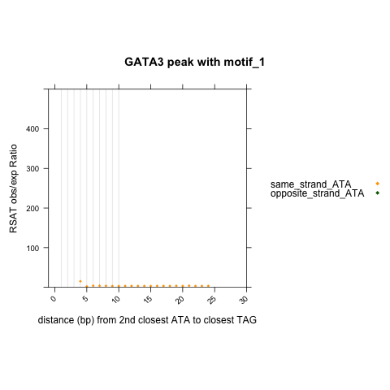

Figure 24: xy plot of rsat analysis for GATA3 peak with motif12456: 3mer structure

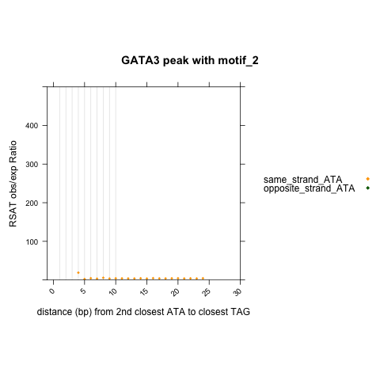

Figure 25: xy plot of rsat analysis for GATA3 peak with motif12456: 3mer structure

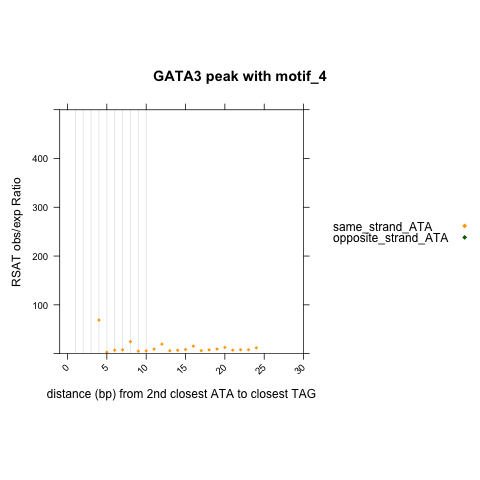

Figure 26: xy plot of rsat analysis for GATA3 peak with motif12456: 3mer structure

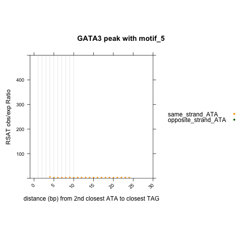

Figure 27: xy plot of rsat analysis for GATA3 peak with motif12456: 3mer structure

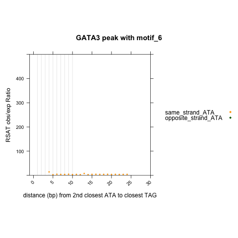

Figure 28: xy plot of rsat analysis for GATA3 peak with motif12456: 3mer structure

```r
library(lattice)
library(latticeExtra)
library(Biostrings)
my_motifs = c("motif_1", "motif_4","motif_2", "motif_6", "motif_5")
Anchor_dyad = c("TAG")
Query_dyad =c("ATA")
compute_dis_df=read.csv('pattern_anchor_at_G_compute_dis.csv')

for (motif in my_motifs) {
  print(motif)
  rsat_results=paste0("GATA3_peak_161win_with_", motif, "_RSAT_dyad.txt")
  for (pattern1 in Anchor_dyad){
    print(pattern1)
    for (pattern2 in Query_dyad){
      print(pattern2)
      number1=compute_dis_df[compute_dis_df$pattern==pattern1, "anchor"] + compute_dis_df[compute_dis_df$pattern==pattern2, "query"]
      rc_pattern2=reverseComplement(DNAString(pattern2))
      print(rc_pattern2)
      number2=compute_dis_df[compute_dis_df$pattern==pattern1, "anchor"] + compute_dis_df[compute_dis_df$pattern==as.character(rc_pattern2), "query"]

      ss <- process_and_subset_RSAT(rsat_results, pattern1, pattern2, number1)
      os <- process_and_subset_RSAT(rsat_results, pattern1, rc_pattern2, number2)

      if(nrow(ss) > 0) {
                        ss$query_status <- paste0("same_strand_", pattern2)
                        } else {
                        ss <- data.frame(matrix(NA, ncol = ncol(ss), nrow = 1)) # Fill ss dataframe with NA values for all columns
                        colnames(ss) <- c("first", "dyad_distance", "second", "ratio","relative_distance")
                        ss$query_status <- paste0("same_strand_", pattern2)
                        }

      if(nrow(os) > 0) {
                        os$query_status <- paste0("opposite_strand_", pattern2)
                        } else {
                        os <- data.frame(matrix(NA, ncol = ncol(os), nrow = 1)) # Fill os dataframe with NA values for all columns
                        colnames(os) <- c("first", "dyad_distance", "second", "ratio","relative_distance")
                        os$query_status <- paste0("opposite_strand_", pattern2)
                        }

      df.plot=rbind(ss, os)
      df.plot$query_status = factor(df.plot$query_status, levels = c(paste0("same_strand_", pattern2), paste0("opposite_strand_", pattern2)))

      # xy plot
      png(paste0('xy_RSAT_dyad_closest_2nd_', pattern2, '_to_closest_1st_', pattern1, '_to_GATA3_pos_', motif, '_compare_to_DHS.png'))
      print(xyplot(ratio ~ relative_distance,
                   data = df.plot,
                   groups = query_status,
                   auto.key=list(space="right", points=TRUE),
                   aspect = 1,
                   xlim=c(-1,30),
                   ylim=c(0, 500),
                   xlab = paste0("distance (bp) from 2nd closest ",pattern2, " to closest ", pattern1),
                   ylab="RSAT obs/exp Ratio",
                    main=paste0("GATA3 peak with ", motif),
                   between=list(y=1.0),
                   scales = list(x = list(rot = 45, at = seq(from = 0, to = 50, by = 5))),
                   par.settings = list(superpose.symbol = list(col=c("orange", "darkgreen"), pch=18, lwd=2), strip.background=list(col="grey85")),
                   panel = function(x,y,...) {panel.abline(v=c(seq(1, 10, 1)), col = "grey90")
                                              panel.xyplot(x, y,
                                                           col=c("orange","darkgreen"),
                                                           pch=18,
                                                           cex=0.6,...)
                                              #panel.barchart(x,y, horizontal = FALSE, col=c("red", "blue"), alpha=0.4)


                 }))
     dev.off()
    }
  }
}
```